```python
from IPython.display import display
from IPython.display import HTML
import IPython.core.display as di # Example: di.display_html('<h3>%s:</h3>' % str, raw=True)

# This line will hide code by default when the notebook is exported as HTML
di.display_html("""
    <script>
        function show_code() {
            jQuery(".input_area").toggle();
            jQuery(".prompt").toggle();
            jQuery("#notebook-container").toggleClass("closed_notebook");
        }
    </script>
""", raw=True)

# This line will add a button to toggle visibility of code blocks, for use with the HTML export version
di.display_html('''<button onclick="show_code()">Show/hide code</button>''', raw=True)
```

[figure not shown]

# A digital approach to palaeography

*Tesina* for *Mathematics in Machine Learning* course by **Michele Panariello**

1. Data exploration
2. Outlier detection
3. Baseline: LDA & QDA
4. Support Vector Machines
5. Logistic regression
6. Ridge Classifier / Least Squares SVM
7. K-Nearest-Neighbors
8. Decision trees and random forests
9. Final evaluation on test set
10. References

[figure not shown]

We present an analysis of the [Avila dataset](https://archive.ics.uci.edu/ml/datasets/Avila), which contains features extracted from 800 images of the *Avila Bible* (*Biblia de Ávila*), a giant Latin copy of the Bible produced during the XII century between Italy and Spain *(De Stefano, 2018)*.  
Each record of the dataset containts **11 attributes pertaining to a group of 4 consecutive rows** of the tome averaged together. We refer to each group of 4 rows as a *pattern*. The attributes of a pattern represent several palaeographic characteristics that were inferred from a digital scan of each page. Rubricated letters and miniatures were excluded from the scans.

The palaeographic analysis performed on the Avila Bible established that the manuscript contains pages written by 12 different scribe monks throughout the years. The goal of this analysis is to **identify which scribe is the author of a certain pattern** based on the available attributes. This makes the task a **classification problem** in which the **copyist monk constitutes the class to predict**.

To shorten computation times and to ease the illustation of the behavior of certain algorithms, we restrict our analysis to the patterns associated to 6 out of the 12 scribes. **According to the available documentation, the attributes of dataset have already been standardized**. A short description of the available attributes follows.

## Attributes description

- **Page level features**:
  - `intercolumnar distance`: distance between two columns of a page
  - `upper margin`: distance between upper margin of the page and first line of text
  - `lower margin`: distance between lower margin of the page and last line of text
- **Column level features**:
  - `exploitation`: fraction of the column filled with ink. Formally computed as $N_{BP}(C)\,/\,N_P(C)$, where $N_{BP}(C)$ and $N_P(C)$ are the number of black pixels and the number of total pixels in the current column, respectively.
  - `row number`: number of rows in the current column
- **Row level features**:
  - `modular ratio`: estimation of the dimension of the handwritten character
  - `interlinear spacing`: distance between two rows, in pixels
  - `weight`: fraction of row filled with ink. Analogous to exploitation, but for a single row
  - `peak number`: estimation of the number of characters in a row
  - `modular ratio/ interlinear spacing`: ratio of the two preceding attributes

All attributes are quantitative (i.e. numerical). The target variable is assigned the name `monk`; it is the only qualitative attribute of the dataset. Each copyist is denoted with a different letter.

**Importing libraries and dataset.**

```python
use_plotly = False
```

```python
import pandas as pd
import numpy as np
import seaborn as sns
from matplotlib import pyplot as plt
from plotly import figure_factory as ff
from plotly.subplots import make_subplots
from os.path import exists
from IPython.utils import io
from mlxtend.plotting import plot_decision_regions
from ast import literal_eval

if use_plotly:
    import plotly.graph_objects as go
    import plotly.express as px

import warnings
warnings.filterwarnings('ignore')

plt.rcParams['axes.prop_cycle'] = plt.cycler(color=plt.cm.Dark2.colors)
```

```python
from os.path import isdir
if not isdir('avila'):
  !curl 'https://archive.ics.uci.edu/ml/machine-learning-databases/00459/avila.zip' --output avila.zip
  !unzip avila.zip
  !rm avila.zip

train_path = 'avila/avila-tr.txt'
test_path = 'avila/avila-ts.txt'
random_state = 1153
```

```python
names = [
  'intercolumnar distance',
  'upper margin',
  'lower margin',
  'exploitation',
  'row number',
  'modular ratio',
  'interlinear spacing',
  'weight',
  'peak number',
  'modular ratio/ interlinear spacing',
  'monk'
]

avila_tr = pd.read_csv(train_path, names=names)
avila_ts = pd.read_csv(test_path, names=names)
to_keep = ['A', 'F', 'E', 'X', 'I', 'H']

avila = avila_tr[avila_tr['monk'].isin(to_keep)]
# avila = avila.drop('modular ratio/ interlinear spacing', axis=1)

avila_test = avila_ts[avila_ts['monk'].isin(to_keep)]
# avila_test = avila_test.drop('modular ratio/ interlinear spacing', axis=1)

del avila_tr
del avila_ts

avila['monk'] = avila['monk'].astype('category')
avila_test['monk'] = avila_test['monk'].astype('category')
print('Dataset imported.')
print(f"Dataset size: {len(avila)}")
print(f'Dataset columns: {avila.shape[1]}')
```

```
Dataset imported.
Dataset size: 9214
Dataset columns: 11
```

# Data exploration

The initial phase of the analysis consists in exploring the dataset as it is, in order to get a sense of how the data is distributed. We first check for **null values** and examine the **class proportions**.

```python
print('Null values per attribute:')
print(np.sum(avila.isna()))
```

```
Null values per attribute:
intercolumnar distance                0
upper margin                          0
lower margin                          0
exploitation                          0
row number                            0
modular ratio                         0
interlinear spacing                   0
weight                                0
peak number                           0
modular ratio/ interlinear spacing    0
monk                                  0
dtype: int64
```

The dataset contains **no null values**.

```python
if use_plotly:
    class_bar = px.bar(avila['monk'].value_counts(),
           x=avila['monk'].value_counts().index,
           y=avila['monk'].value_counts(),
           color=avila['monk'].value_counts().index,
           text=avila['monk'].value_counts(),
           color_discrete_sequence = px.colors.qualitative.Antique,
           title=dict(text='Occurrence of each class', x=0.5, xanchor='center'),
           width=800, height=400,
          )

    class_bar.update_layout(showlegend=False, xaxis_title='Monk', yaxis_title='Occurences',  margin=dict(t=50, b=25, r=20), hovermode=False)
    class_bar.update_traces(textposition='outside')
    class_bar.show()
```

[figure not shown]

The class distribution is evidently **not balanced**.

As previously mentioned, the documentation of the Avila dataset states that the data is already standardized. We shall now verify the truthfullness of that statement.

## Standardization

> *Standardization* is a preprocessing technique that attempts to make the individual **distributions of the attributes of the dataset more homogenous and comparable with one another**.

> Let $x_{ij}$ be the $j^{th}$ component of sample $\mathbf{x}_i$. Then we standardize it to $\tilde x_{ij}$ as follows:

> $$\tilde x_{ij}=\frac{x_{ij}-\mu_j}{\sigma_j}$$

> Where $\mu_j=\frac{1}{N}\sum_i{x_{ij}}$ and $\sigma_j=\sqrt{\frac{1}{N-1}\sum_i{(x_{ij}-\mu_j)^2}}$ are the **mean and the standard deviation** of the $j^{th}$ column, respectively.  
> Standardization ensures that no attribute of the dataset takes over all the others when computing distances between points: several algorithms, such as SVM and kNN, can greatly benefit from this.

Contrary to what is stated in the documentation, not all attributes are standardized. Most of the column means are reasonably close to zero; however, **several standard deviations are above $1$**, some going as high as $4.13$.

```python
avila.describe()
```

|  | intercolumnar distance | upper margin | lower margin | exploitation | row number | modular ratio | interlinear spacing | weight | peak number | modular ratio/ interlinear spacing |
| --- | --- | --- | --- | --- | --- | --- | --- | --- | --- | --- |
| count | 9214.000000 | 9214.000000 | 9214.000000 | 9214.000000 | 9214.000000 | 9214.000000 | 9214.000000 | 9214.000000 | 9214.000000 | 9214.000000 |
| mean | 0.031404 | 0.009093 | -0.013331 | -0.009419 | 0.011210 | 0.017567 | 0.021823 | 0.011845 | -0.000985 | -0.012831 |
| std | 1.022200 | 4.132939 | 1.103805 | 1.016610 | 0.980905 | 1.124883 | 1.341160 | 1.012298 | 1.107358 | 0.978390 |
| min | -3.498799 | -2.426761 | -3.210528 | -5.440122 | -4.922215 | -7.450257 | -11.935457 | -4.247781 | -5.486218 | -6.719324 |
| 25% | -0.104241 | -0.267686 | 0.068476 | -0.544980 | 0.172340 | -0.598658 | -0.044076 | -0.545938 | -0.372457 | -0.498106 |
| 50% | 0.068573 | -0.063555 | 0.214288 | 0.120230 | 0.261718 | -0.058835 | 0.220177 | 0.117016 | 0.064084 | -0.031505 |
| 75% | 0.229043 | 0.179832 | 0.342319 | 0.643738 | 0.261718 | 0.564038 | 0.446679 | 0.662303 | 0.500624 | 0.511416 |
| max | 11.819916 | 386.000000 | 50.000000 | 3.987152 | 1.066121 | 53.000000 | 83.000000 | 13.173081 | 44.000000 | 4.048692 |

- `upper margin`
- `lower margin`
- `modular ratio`
- `interlinear spacing`

It is possible to use a boxplot to quickly inspect the distribution of a single feature. In particular, we wish to inspect the most evidently non-standard: `upper margin`.

## Boxplots

> A *boxplot* can be described as a **five-number summary of a univariate dataset**. Such numbers are usually represented by graphical means as a shape similar to a box (hence the name *boxplot*) with two lateral bars called *whiskers*. The length of the bars roughly represents how "spread out" the data is.

> The 5 points which summarize the data are computed as follows:
> - **First quartile ($Q1$)**: the point below which lies 25% of the data points
> - **Second quartile (median or $Q2$)**: the point below which lies 50% of the data points
> - **Third quartile ($Q3$)**: the point below which lies 75% of the data points
> - **Inter-Quartile Range $(IQR)$**: computed as $Q3-Q1$
> - **Maximum**: computed as $Q3+\frac{3}{2}IQR$
> - **Minimum** computed as $Q1-\frac{3}{2}IQR$

> It is worth remining that, contrary to what the name might suggest, **maximum** and **minimum** are **NOT** the maximum and the minimum points of the dataset in a strict mathematical sense. Instead, they are values that are employed to encompass the region where most of the points of the dataset should reasonably lie, under the assumption that they are centered around the mean.  
> Indeed, it is common practice to **consider as outliers those points that lie outside the whiskers** of the box.

[figure not shown]

```python
def single_boxplot(df, colname) -> None:
  """
  Draws a single horizontal boxplot of the column 'colname' of the given dataframe.

  Args:
    df (pandas DataFrame): dataset
    colname (str): name of the column t plot
  """
  box = px.box(x=df[colname], orientation='h', height=200, color_discrete_sequence = px.colors.qualitative.Antique)
  box.update_layout(xaxis_title=colname, margin=dict(t=10, b=10, r=10, l=10), hovermode=False)
  box.show()
```

```python
if use_plotly:
    single_boxplot(avila, 'upper margin')
```

[figure not shown]

Clearly, there is **one anomalous point** in the dataset: it is so far away from the median that the whiskers are not even visibile. We can remove the point right away.

```python
new_std = avila['upper margin'][avila['upper margin'] < 50].std()
print(f"Standard deviation of attribute 'upper margin' with outlier removed: {new_std:.3}")
avila = avila[avila['upper margin'] < 50]
```

```
Standard deviation of attribute 'upper margin' with outlier removed: 0.953
```

Without that point, the dataset is (reasonably) normalized.

```python
avila.describe()
```

|  | intercolumnar distance | upper margin | lower margin | exploitation | row number | modular ratio | interlinear spacing | weight | peak number | modular ratio/ interlinear spacing |
| --- | --- | --- | --- | --- | --- | --- | --- | --- | --- | --- |
| count | 9213.000000 | 9213.000000 | 9213.000000 | 9213.000000 | 9213.000000 | 9213.000000 | 9213.000000 | 9213.000000 | 9213.000000 | 9213.000000 |
| mean | 0.031407 | -0.032804 | -0.018759 | -0.009438 | 0.011211 | 0.011816 | 0.012816 | 0.011817 | -0.005761 | -0.012902 |
| std | 1.022256 | 0.952851 | 0.973118 | 1.016664 | 0.980958 | 0.980173 | 1.025373 | 1.012350 | 1.008059 | 0.978420 |
| min | -3.498799 | -2.426761 | -3.210528 | -5.440122 | -4.922215 | -7.450257 | -11.935457 | -4.247781 | -5.486218 | -6.719324 |
| 25% | -0.104241 | -0.267686 | 0.068476 | -0.544980 | 0.172340 | -0.598658 | -0.044076 | -0.546001 | -0.372457 | -0.498118 |
| 50% | 0.068573 | -0.063555 | 0.214288 | 0.120230 | 0.261718 | -0.058835 | 0.220177 | 0.117016 | 0.064084 | -0.031608 |
| 75% | 0.229043 | 0.179832 | 0.342319 | 0.643738 | 0.261718 | 0.564038 | 0.446679 | 0.662337 | 0.500624 | 0.511054 |
| max | 11.819916 | 43.133656 | 7.419561 | 3.987152 | 1.066121 | 4.882622 | 10.714792 | 13.173081 | 3.244594 | 4.048692 |

Now that all attibutes are normalized, and hence on the same scale, it is possible to **compare their distributions with individual boxplots**.

```python
def dataset_box_by_feature(ds) -> None:
  """
  Plot the boxplots of the given dataset, by column.

  Args:
    ds (pandas DataFrame): dataset to plot
  """
  tot_fig = go.Figure()
  for column in ds.columns:
    tot_fig.add_trace(
        go.Box(
          y=ds[column],
          name=column,
      )
    )

  tot_fig.update_layout(
      margin=dict(
          l=20,
          r=20,
          b=20,
          t=50,
          pad=0
      ),
      title={'text': f'Attributes of the dataset ({len(ds)} samples)', 'x': 0.5, 'xanchor': 'center'},
      showlegend=False
  )
  tot_fig.show()
```

```python
if use_plotly:
    dataset_box_by_feature(avila)
```

[figure not shown]

According to the boxplots, all attributes seem to contain several anomalous values: in particular, one point with an upper margin of $40$ makes it hard to correctly visualize the boxes.  
Hence, several **outlier removal** techniques will be considered in the following sections. Prior to that, we inspect some other properties of the data.

## Correlation matrix

> A correlation matrix is a matrix which contains, for each possible couple of attributes $X$ and $Y$ in the dataset, the *Pearson correlation coefficient* between $X$ and $Y$, defined as

> $$\rho_{X,Y}=\frac{Cov(X,Y)}{\sigma_{X}\sigma_{Y}}\in[-1,1]$$

> Where $Cov(X,Y)=\frac{1}{N-1}\sum_{i}{(x_i-\mu_X)(y_i-\mu_Y)}$.

> By graphically illustrating a correlation matrix in the form of an **heatmap**, it is possible to quickly assess whether some attributes of the dataset have very positive or very negative correlation.  
> A correlation close to $+1$ or $-1$ indicates that the two attributes $X$ and $Y$ behave as if they had some linear relationship of the kind $Y=cX$, with $c$ having the same sign of $\pm1$. However, said underlying relationship is not guaranteed to exist: this is often summarized with the statement *correlation does not imply causation*.

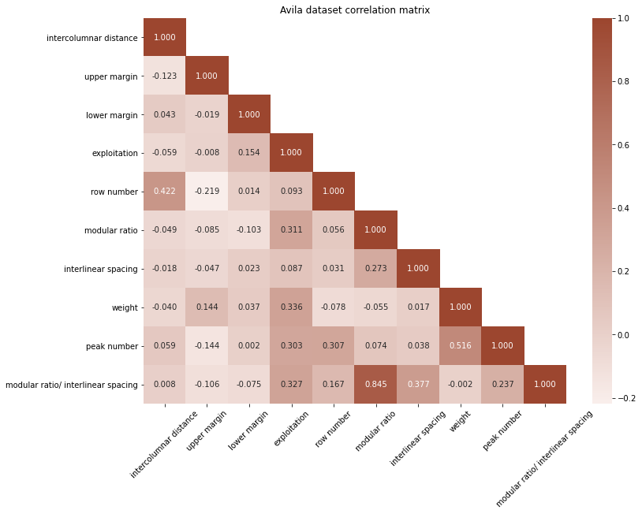

```python
corr = avila.corr()
hm_fig, hm_ax = plt.subplots(figsize=(12,9))
mask = np.logical_not(np.tril(np.ones_like(corr, dtype=np.bool)))
sns.heatmap(
    corr,
    annot=True,
    mask=mask,
    fmt='.3f',
    ax=hm_ax,
    cmap=sns.light_palette('#9c462f', n_colors=300),
)
hm_ax.set_xticklabels(hm_ax.get_xticklabels(), rotation=45)
hm_ax.set_title('Avila dataset correlation matrix')
hm_ax.patch.set_alpha(0);
```

The correlation matrix reveals a **high correlation** between the attributes `modular ratio` and `modular ratio/ interlinear spacing`. This is reasonable, since the latter is just the former divided by `interlinear spacing`. According to *(De Stefano, 2018)*, the attribute `modular ratio/ interlinear spacing` is misleading when trying to solve the clasifiction task using a MLP with 100 hidden neurons. We are not going to use any kind of neural network in this analysis, but we still remove the `modular ratio/ interlinear spacing` attribute because of its high correlation with `modular ratio`.

Other couples of features that ehxibit a remarkable correlation coefficient are:

- `weight` and `peak number` ($0.516$). Intuitively, this is reasonable: recall that the former is the fraction of the row space occupied by the ink, and the latter is an estimation of the number of characters in a row. It makes sense to think that, if a row contains a lot of characters, then it will probably be more occupied by ink than the average.
- `intercolumnar distance` and `row number` ($0.422$). From a purely intutitive standpoint, this correlation is likely to be spurious. We shall better asses this with a graphical comparison of the two attributes.

## Pair plots

> A *pair plot* is a set of graphs that illustrates all the possible pairs of predictors of a dataset plotted one against the other.  
> It can be used for a quick visual overview of how different attributes interact with each other.

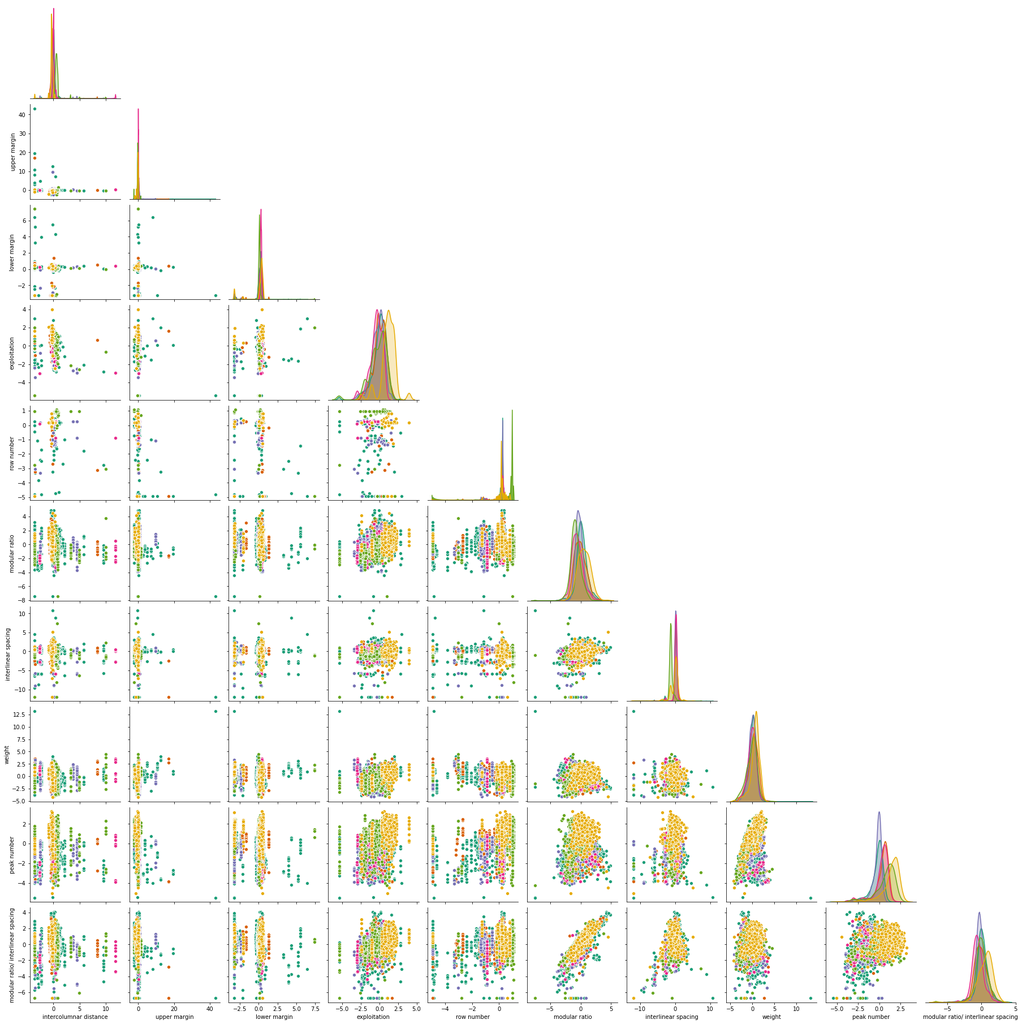

```python
pairpl = sns.pairplot(avila, hue='monk', diag_kind='kde', corner=True);
pairpl._legend.remove()
```

The plot of the pair `weight` and `peak number` seems to confirm that there is some relationship of mutual growth between the two, which results in a fanning effect in the distribution of points.

On the other hand, there is **no clearly visible linear relationship** between `intercolumnar distance` and `row number`. Thus, the high correlation may be due to noise.

**Noise actually seems to be one of the main problems of the dataset**: several isolated points are visible in marginal positions of the graphs. Some of them tend to stretch out the range of the representation and do not allow a thorough visual inspection of the pair plots. We shall address this issue in the next section.

The following is concluded about the highly correlated attributes:

- `modular ratio/ interlinear spacing` is removed
- both `intercolumnar distance` and `row number` are kept
- `weight` and `peak number` do seem to have some form of correlation, albeit not so critical. We choose to keep both the attributes for the moment, as most algorithms will likely not be hindered by this hint of collinearity. Nonetheless, it is worth to shortly delve into this issue for illustrative purposes.

## Hazards of correlated attributes

> Linear correlation between attributes (also referred to as *multicollinearity*) might consitute a problem mainly on certain kinds of linear models. In the area of classification, the term *linear model* usually indicates an algorithm that infers a vector of coefficients $\mathbf w$ and a bias term $b$ which can be used to linearly transform an input sample to obtain some score $f(\mathbf x)=\mathbf w^T\mathbf x+b$. This score can then be used to predict the label of the sample $\mathbf x$.

> There are 3 main problems that could be caused by having strongly correlated attributes in the data:
> 1. **The computation of $(X^TX)^{-1}$ is numerically unstable**. Inverting $X^TX$ is needed in some linear models that have a closed-form solution (e.g. linear regression). When *perfect multicollinearity* exists (i.e. when two predictors are actually linearly dependent) then $X^TX$ is not invertible.
> 2. **The trained model may have larger variance**, i.e. give more different results for small variations of training data. This is because when one attribute changes, its correlated attribute changes too, making the estimation of the weights $w$ more "unstable".
> 3. For the aforementioned reason, in linear models, tests regarding the $w$ coeffients may become less reliable.

That said, apart from the `modular ratio/ interlinear spacing` case, no correlation coefficient is overly high: thus, we are relatively safe from the illustrated issues.

```python
avila = avila.drop('modular ratio/ interlinear spacing', axis='columns')
avila_test = avila_test.drop('modular ratio/ interlinear spacing', axis='columns')

# Transfering everyting into an X and a y
X = avila.drop('monk', axis='columns')
y = avila['monk']
```

# Outlier detection

We now address the issue of the **noisy observations** within the dataset. In data analysis, there are two main practices related to the detection of data points with abnormal values:

- **Outlier detection**: The training data contains outliers which are defined as observations that are far from most of the others. Outlier detectors try to enclose the region of data where relevant information lies, leaving out noise.
- **Novelty detection**: an algorithm is trained on data that does NOT contain outliers. The algorithm must detect the presenct of novelties (i.e. abnormal observations) in data that it is given after the training step.

Before starting, we try to better visualize the distribution of each feature, divided by class.

```python
def dataset_rug(data, labels, additional_title=None):
  """
  Displays one rug plot for each different feature of the dataset. Each rug is divided by label.

  Args:
    data (pandas DataFrame): the dataset to display
    labels (pandas series or np.array): labels of the dataset
    additional_title (str or None): string to display in brackets after main title. If None, nothing is shown.
  """
  n_rows = int(np.ceil(len(data.columns)/2).astype(int))
  row_col = [(i,j) for i in range(1, n_rows+1) for j in (1,2)][:len(data.columns)]
  title = f'[{len(data)} points]'
  if additional_title:
    title = additional_title + ' ' + title

  fig = make_subplots(
      rows=n_rows, cols=2,
      horizontal_spacing=0.03,
      vertical_spacing=0.1,
      subplot_titles=(data.columns)
  )

  fig.update_layout(
      margin=dict(t=50, b=25, r=20, l=20),
      showlegend=False,
      title={'text': title, 'x': 0.5, 'xanchor': 'center'},
      height=900
  )

  for column, (row, col) in zip(data.columns, row_col):
    fig.add_trace(
        go.Scatter(
            x=data[column],
            y=labels,
            mode='markers',
            marker=go.scatter.Marker(
              color=labels.cat.codes,
              symbol='line-ns-open',
              colorscale=['red', 'green', 'blue']
          )
        ),
        row=row,
        col=col
    )

  fig.show()
```

```python
if use_plotly:
    dataset_rug(X, y, additional_title='Full avila')
```

[figure not shown]

## Isolation forest

> *Isolation Forest* is an unsupervised outlier and anomaly detection algorithm introduced by *(Liu, 2008)* based on **ensembles of data strctures called *Isolation Trees* (*iTrees*).** The function of each tree is to try to **isolate each point of the dataset** by performing random splits on one feature at a time. We now describe how to construct an isolation tree and illustrate the workings of the algorithm.

### 1) iTrees

> A tree is grown until it reaches some maximum depth or **up to when its leaves contain one or zero samples**. At each node of the tree, the data is recursively split on a **random attribute**, and on a **random value** within the range of that attribute.  
> Each *iTree* is trained on a **subset $\psi$ of the complete dataset** according to the following pseudocode:

> ```
> iTree(X, e, l):
>  // X=dataset, e=current tree height, l=height limit
>  if e >= l or |x|<=1:
>    return a terminal node
>  else:
>    randomly select and attribute q
>    randomly select a value p in the range of q
>    Xl <- {x ∈ X : x[q]<p}
>    Xr <- {x ∈ X : x[q]>=p}
>    return a node in which
>      left child <- iTree(Xl, e+1, l)
>      right child <- iTree(Xr, e+1, l)
> ```

> $l$ is usually chosen as an **estimation of the average height** of a generic binary tree:

> $$l=\lceil{\log_2{|\psi|}}\rceil$$

> The size of $\psi$ recommended by the authors is $256$. We choose to leave it that way, since the original paper claims satisfactory results with it on both bigger and smaller datasets than Avila. Training *iTrees* on subsets of data rather than the whole dataset is helpful for two reasons:
> - it reduces memory usage.
> - if several outliers are clustered, they can be split up and be isolated by the trees more easiliy.

[figure not shown]

### 2) Training the ensemble

> Any number of *iTrees* can be trained on subsets $\psi$ of the whole dataset, obtaining an *Isolation Forest*.

### 3) Outlier score

> We can now compute an outlier score for any given sample $x$ based on the following principle: **if, on average, it is possible to isolate $x$ with a low number of splits, then it is probably an outlier.**

> First, $x$ is passed through each *iTree*. The length of the path from the root to the leaf $x$ ended up in is computed as $h(x)$.

> The outlier score of $x$ is:

> $$s(x)=2\hat{}\left(-\frac{E(h(x))}{c(n)}\right)$$

> where $c(n)=2H(n-1)-\frac{2(n-1)}{n}$ is a more precise estimation of the average height of an *iTree* for a dataset of $n$ instances. $H(i)\approx\ln(i)+0.577$.

> The **higher the score** of a point is, the **more likely** it is to be an **outlier**.
> - $s(x)\approx 1$ indicates almost surely an outlier (since $E(h(x))\ll c(n)$)
> - $s(x)\approx 0.5$ means it took an average number of splits to isolate $x$ (since $E(h(x))\approx c(n)$), hence $x$ is not an outlier

[figure not shown]

```python
contamination = 200/len(X)
```

```python
from sklearn.ensemble import IsolationForest

isol_for = IsolationForest(n_estimators=500, random_state=random_state, contamination=contamination, behaviour='new')
isol_for.fit(X)
s_scores = -isol_for.score_samples(X)
```

We can observe the distribution of $s$ scores by plotting an elbow graph. This way, we can select what threshold roughly corresponds to the amount of outliers we estimate to be in the dataset.

```python
def simple_line(x, title_text='Line plot', y_label='y'):
  """
  Show a simple line graph of data x.
  """
  sl = px.line(
    y=x,
    title={'text': title_text, 'x': 0.5, 'xanchor': 'center'},
    width=700, height=400,
    color_discrete_sequence = px.colors.qualitative.Antique
  )
  sl.update_layout(xaxis_title='Sample', yaxis_title=y_label,  margin=dict(t=50, b=25, r=20))
  sl.update_traces(hovertemplate=y_label + ': %{y}<br>Number of samples: %{x}')
  sl.show()
```

```python
if use_plotly:
    simple_line(-np.sort(-s_scores), 'Ordered s-score from Isolation Forest', 's-score')
```

[figure not shown]

We choose a cutoff point of $0.59$, which roughly corresponds to $200$ outliers.

```python
s_threshold = 0.59
print(f'Using threshold {s_threshold}')
print(f'{y[s_scores > s_threshold].size} outilers found by Isolation Forest, with distibution')
print(y[s_scores > s_threshold].value_counts())
```

```
Using threshold 0.59
190 outilers found by Isolation Forest, with distibution
A    129
I     29
F     15
X      7
E      7
H      3
Name: monk, dtype: int64
```

We graphically inspect the distribution of the outliers caught by the *Isolation Forest*, and verify that several extreme points are caught by the model.

```python
outliers_mask = (s_scores > s_threshold)
data = X[outliers_mask]
labels = y[outliers_mask]

if use_plotly:
    dataset_rug(data, labels, additional_title='Outliers caught by Isolation Forest')
```

[figure not shown]

## Local Outlier Factor (LOF)

> LOF is a **density-based** outlier detection algorithm proposed in *(Breunig, 2000)*. It revolves around the concept of establishing a measure of **"local density"** of the space surronding a given data point. If a point $x$ has a **lower local density than the average local density of its k-nearest neighbors, then it is probably an outlier**.

> We now introduce several concepts and metrics that lead to the definition of a local density measure. Let $p$ be a point in a feature space.
> 1. We call $k\text{-}dist(p)$ the distance of $p$ from its $k^{th}$ nearest neighbor.
> 2. We define $N_k(p)$ the set of points whose distance from $p$ is at most $k\text{-}dist(p)$. This is a broader definition of a set of k-nearest-neighbors: the set can contain more than $k$ points, if two of them are equally far from $p$.

> $$N_k(p)=\{x:d(p,x)\leq k\text{-}dist(p)\}$$
> 1. We define the *k-reachability distance* of $p$ as a metric that "pushes" a point $x$ away from $p$ to a distance of $k\text{-}dist(p)$, if $x$ was originally closer than that to $p$.

> $$k\text{-}reach\text{-}dist(x,p)=\max \{ k\text{-}dist(p),\;d(x,p)\}$$

[figure not shown]

> This is not a distance in the strict sense of the word, since it is asymmetrical. In particular, $k\text{-}reach\text{-}dist(x,p)$ will be equal to $d(x,p)$ if point $p$ is very crowded; however, if $p$ is isolated, $x$ will likely fall among its k-nearest neighbors, and will therefore be pushed away. Overall, one could say that $k\text{-}reach\text{-}dist(x,p)$ will grow larger than normal if $p$ is isolated.

> With that in mind, we can state the following: given a point $A$ and its k-nearest neighbors $B_i\in N_k(p)$, **a high average value of $k\text{-}reach\text{-}dist(A,B_i)$ indicates that $A$ is isolated**.
> 1. We define *k-local reachability density* of $A$ as the inverse of the average k-reachability distance of A from its k-nearest neighbors. If it is low, then the neighbors of $A$ tends to be isolated from its neighbors.

> $$lrd_k(A)=\frac{|N_k(A)|}{\sum_{B\in N_k(A)}{k\text{-}reach\text{-}dist(A,B)}}$$

> Finally, we can define the *k-Local Density Factor of $A$* as the ratio between the average local density of the k-nearest neighbors of $A$ and the local density of $A$ itself.

> $$LOF_k(A)=\frac{\sum_{B\in N_k(A)}{ldr_k(B)}/|N_k(A)|}{ldr_k(A)}$$

> **If $LOF_k(A)\gg 1$, then the neighbors of $A$ have a higher local density than $A$ itself, and $A$ is probably an outlier.**

[figure not shown]

This techinque has one main problem: choosing the right hyperparameter $k$ is anything but easy. *(Breunig, 2000)* proposes a heuristic method whereby an upper and lower buond for $k$ is determined and all values of $LOF_k(x)$ are compared for $k\in [k_{max}, k_{min}]$. We follow a simpler approach and just leave the default $k$ parameter set by scikit-learn.

```python
from sklearn.neighbors import LocalOutlierFactor

lof = LocalOutlierFactor(contamination=contamination).fit(X)
lof_scores = -lof.negative_outlier_factor_
```

```python
if use_plotly:
    simple_line(-np.sort(-lof_scores), title_text='Local Oulier Factor scores', y_label='LOF score')
```

[figure not shown]

Again, we set the $LOF$ threshold to select about $200$ outliers.

```python
lof_threshold = 1.68
print(f'Using threshold {lof_threshold}')
print(f'{y[lof_scores > lof_threshold].size} outilers found by LOF, with distibution')
print(y[lof_scores > lof_threshold].value_counts())
```

```
Using threshold 1.68
193 outilers found by LOF, with distibution
A    106
X     35
I     24
E     21
F      5
H      2
Name: monk, dtype: int64
```

```python
outliers_mask = (lof_scores > lof_threshold)
data = X[outliers_mask]
labels = y[outliers_mask]

if use_plotly:
    dataset_rug(data, labels, additional_title='Outliers caught by LOF')
```

[figure not shown]

LOF and Isolation Forest operate in a very different manner, and therefore make very different choices: we can verify that the intersection between the outiler sets found by iForest and LOF is relatively small.

```python
n_common_outl = np.sum((lof_scores > lof_threshold) & (s_scores > s_threshold))
print(f'Number of common outilers between Isolation Forest and LOF: {n_common_outl}')
```

```
Number of common outilers between Isolation Forest and LOF: 27
```

The last outlier detection methods we explore are SVM-based.

## One-Class SVM and SVDD

> Proposed by (Schölkopf, 1999), a *One-Class SVM* is an outlier and novelty detection algorithm which **attempts to separate all data points of the dataset from the origin** by following an approach similar to that of a classic Support Vector Machine *(Vapnik, 1995)*.

> The decision function which the algorithm tries to learn is of the form

> $$f(x)=\text{sgn}(w^T\phi(x)-\rho)$$

> which will return **$+1$ for points on the side of the data cloud, and $-1$ for points closer to the origin**. The goal is to find the hyperplane $w^T\phi(x)-\rho =0$ which best separates the dataset from the origin, while also:
> - minimizing $\|w\|$ for regularization
> - minimizing the values of slack variables
> - maximizing the intercept $\rho$

> Therefore, the optimization problem of the One-Class SVM becomes

> $$\min_{w,\,\xi_i,\,\rho}\frac{1}{2}\|w\|^2+\frac{1}{\nu N}\sum_{i=1}^N{\xi_i}-\rho$$$$\text{s.t.}\quad w^T\phi(x_i)\geq \rho -\xi_i\quad \text{and}\quad \xi_i\geq 0\quad \forall i=1\dots N$$

> $\nu\in (0,1)$ is an **hyperparameter**. It is possible to prove that **$\nu$ can be interpreted as an upper bound of the fraction of points in the training set that will be considered outliers** by the algorithm. For example, if we expect that noise consitutes no more than $10\%$ of the data, we can set $\nu = 0.1$

> Notice that, without slack variables, the first constraint would become $w^T\phi(x_i)- \rho\geq 0$, i.e. *all points must be above the hyperplane*.

Similarly to an ordinary SVM, the problem can be rewritten in dual form to obtain from the lagrange multipliers an $\alpha_i$ coefficient for each point: it will be **nonzero only for support vectors**. A more accurate description of the theoretical concepts underlying Support Vector Machines will be given later on.

Moreover, like all SVMs, One-Class SVM can be **kernelized**. In fact, wihtout kernelization, the algorithm is not really flexible and can be applied only to a limited range of scenarios.  
Wihtout the use of a kernel, a similar, but more flexible option is constituted by the **Support Vector Data Description** *(Tax, 2004)*.

> A *SVDD* attempts to **find the hypershpere of minimum radius which encloses all data points within it**, while allowing some mistakes to reduce overfitting.  
> After the training stage, **the points that lie outside the found hypersphere are considered outliers**.

> The optimization problem solved by the SVDD is:

> $$\min_{R,\,a,\,\xi_i}R^2+C\sum_i{\xi_i}$$$$\text{s.t.}\quad \|\phi(x_i)-a\|^2\leq R^2+\xi_i \quad\text{and}\quad \xi_i\geq 0\quad\forall i$$

> The resulting decision function returns $+1$ if the argument is within the found hypersphere, $-1$ otherwise. Again, it is possible to write the dual version of the above problem and kernelize the algorithm.

[figure not shown]

```python
from sklearn.svm import OneClassSVM

ocsvm = OneClassSVM(nu=0.02)
out = ocsvm.fit_predict(X)
tot = np.sum(out == -1)
print(f'Outliers found by One Class SVM: {tot}')
```

```
Outliers found by One Class SVM: 211
```

```python
outl_comm_svdd_isfor = np.sum((out == -1) & (s_scores > s_threshold))
print(f'Number of common outilers between Isolation Forest and One Class SVM (RBF): {outl_comm_svdd_isfor}')
```

```
Number of common outilers between Isolation Forest and One Class SVM (RBF): 95
```

We again visualize the distribution of found outliers with a rug plot.

```python
outliers_mask = (out == -1)
data = X[outliers_mask]
labels = y[outliers_mask]

if use_plotly:
    dataset_rug(data, labels, additional_title='Outliers caught by One Class SVM (RBF kernel)')
```

[figure not shown]

## Additional observations and choice of outlier detection algorithm

By visually inspecting the attributes distribution, it is possible to see that **some features seem to have some common "minimum value"** (see `intercolumnar distance`, `lower margin`, `row number`). Several points, even coming from different classes, cluster around inidividual values, such as $-4.9222$ for `row number`.

We suspect that these values may be caused by the **presence of some specially formatted pages** to which the algorithm employed to digitalize the bible has reacted in the same manner, e.g. blank pages with 0 rows. In that regard, it might be reasonable to assume that the common low value of $-4.9222$ for `row number` might as well correspond to the number $0$, after having been standardized.

If we assume this is true, then there are two consequences:

- the **test data will likely have those extreme values too**: it will be necessary to remove those outliers as well.
- **density-based methods such as *LOF* will be less effective in this scenario**, since several points are clustered in those extreme values. Indeed, the rug plots seem to confirm that *LOF* is catching fewer of those marginal outliers.

Thus, we are left to choose between *Isolation Forest* and *One-Class SVM*. We select the former as outlier/novelty detection algorithm to employ in our pipeline, and move on to the nex step.

```python
points_to_keep = (s_scores <= s_threshold)
X = X[points_to_keep]
y = y[points_to_keep]
print(f'{len(X)} inliers left.')
```

```
9023 inliers left.
```

```python
data = avila[points_to_keep].drop('monk', axis='columns')
labels = avila[points_to_keep]['monk']

if use_plotly:
    dataset_rug(data, labels, additional_title='Dataset after outlier removal')
```

[figure not shown]

After having removed outliers, we must standardize the data to go back to zero mean and unitary standard deviation for all variables.

```python
from sklearn.preprocessing import StandardScaler

std_scaler = StandardScaler()
```

# Baseline: LDA & QDA

We firstly use two simple models to obtain a **baseline** scoring. We do not apply any further processing to the data, for the moment.

> *Quadratic Discriminant Analysis* is a classification techinque which makes use of Bayes' theorem to estimate the conditional probabiliy of the label $y$ given a set of features $x$.

> $$P(y|x)=\frac{P(x|y)P(y)}{P(x)}$$

> *QDA* consists in assuming that each probability $P(x|y=k)$ behaves as a multivariate normal with mean $\mu_k$ and variance-covariance matrix $\Sigma_k$. Formally,

> $$P(x|y=k)=\frac{1}{(2\pi)^{d/2}|\Sigma_k|^{1/2}}\;\exp\left(-\frac{1}{2}(x-\mu_k)^T\Sigma_k^{-1}(x-\mu_k)\right)$$

> Where $d$ is the number of predictors and $|\Sigma_k|$ is the determinant of $\Sigma_k$.  
> By plugging the density of a multivariate normal in Bayes' formula and taking the $\log$, we obtain

> $$\log P(y=k|x)=-\frac{1}{2}\log |\Sigma_k|-\frac{1}{2}(x-\mu_k)^T\Sigma_k^{-1}(x-\mu_k)+\log P(y=k)+P(x)$$

> We can then assign to a sample $x$ the label $k$ which maximizes the expression above.

> $$\hat y=\arg \max_k\big\{\log P(y=k|x)\,\big\}$$

> $x$ appears in a quadratic form in $\log P(y=k|x)$, hence the name of the algorithm. Beacuse $P(x)$ is constant, it can be ignored in the maximization process.

> **By adding the further assumption that the covariance matrices are the same for all classes** (i.e. $\Sigma_k=\Sigma\;\;\forall k$, a scenario known as *homoscedasticity*) **the decision rule can be simplified to obtain a linear boundary** *(Hastie, 2009)*:

> $$\hat y=\arg \max_k \left\{x^T\Sigma^{-1}\mu_k-\frac{1}{2}\mu_k^T\Sigma^{-1}\mu_k+\log P(y=k)\right\}$$

> This variation of the algorithm is therefore called *Linear Discriminant Analysis*.

There is no pre-established rule to determine $P(y)$: it may be arbitrarly decided as a prior, depending on the available domain knowledge, or it can be inferred from the data. In scikit-learn, by default, $P(y=k)=N_k/N$, where $N_k$ is the number of samples belonging to class $k$ and $N$ is the dataset size.  
Similarly, the real values of $\mu_k$ and $\Sigma_k$ will likely be unknown: one possible workaraound is to estimate them as the sample mean and the sample covariance matrix.

LDA and QDA are a very convenient way to set a baseline since **they have no hyperparameters to tune, and they have been shown to work reasonably well with real data** (not only perfectly gaussians distributions) *(Hastie, 2009)*.

Nevertheless, to use *LDA* and *QDA* on the Avila dataset, we choose to drop two attributes that are evidently non-normal when conditioned on different labels: `row number` and `interlinear spacing`. This can be verified by inspecting the rug plot above, or by generating the QQ-plot of the quantiles of the two attributes against the quantiles of the normal distribution.

## Q-Q plot

> A Quantile-Quantile plot is a graphical way of comparing two probability distributions by plotting points $(x,y)$ so that $x$ and $y$ are the same quantiles from the two different distributions.  
> We can attempt to find out if a univariate dataset $X$ is approximately normally distributed by plotting its quantiles against those of a standard normal. If $X$ is normal (not necessarily standard), then the result should be a roughly straight line.

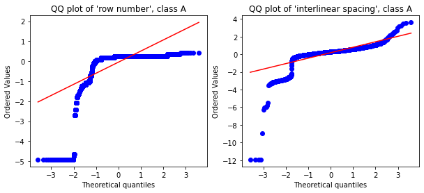

```python
from scipy.stats import probplot
qqlabel = 'A'
figqq, axqq = plt.subplots(1, 2, figsize=(10,4))
probplot(X[y == qqlabel]['row number'], dist='norm', plot=axqq[0])
probplot(X[y == qqlabel]['interlinear spacing'], dist='norm', plot=axqq[1])
axqq[0].set_title(f"QQ plot of 'row number', class {qqlabel}")
axqq[1].set_title(f"QQ plot of 'interlinear spacing', class {qqlabel}");
```

```python
from sklearn.discriminant_analysis import QuadraticDiscriminantAnalysis
from sklearn.discriminant_analysis import LinearDiscriminantAnalysis
from sklearn.pipeline import Pipeline

X_qda = X.drop(['row number', 'interlinear spacing'], axis='columns')

lda_pipe = Pipeline([('standardizer', std_scaler), ('lda', LinearDiscriminantAnalysis())])
qda_pipe = Pipeline([('standardizer', std_scaler), ('qda', QuadraticDiscriminantAnalysis())])
```

## Holdout and cross-validation

We now need a quantitative method to tell whether the two aforementioned models are effective.

### Holdout

[figure not shown]

> Holdout is a simple technique which allows to validate the performance of a machine learning model on a given dataset.  
> When assessing the validity of an algorithm, the most naive option would be to split the available dataset in two parts: **one to train the model, and one to validate the model for the prediction task**. This practice is commonly known as *holdout*. If possible, the split should be carried out so that the class distribution is kept the same in training and validation set: this is known as *stratified sampling*.

### Cross-validation

> While the above approach is very simple and intuitive, it can yield a biased evaluation of the model, since the actual performance measurment was taken only on a subset of the data. One possible alternative is to use the *$k$-fold cross validation* techinque. It consists in the following:
> 1. The dataset is **partitioned into $k$ equally sized parts**, possibly in a *stratified* fashion. These parts are called *folds*
> 2. At the $k^{th}$ step, **the model is trained on all but the $k^{th}$ fold**, and then its performance measurment is taken on the $k^{th}$ fold.
> 3. After $k$ steps, $k$ performance measurments have been obtained. They can now be **summarized** by means of any statistic, usually mean (and possibly standard deviation)

[figure not shown]

> More specifically, given some gain function $G(y, \hat y)$, let $\hat {f}\,{}^{-k}(x)$ be an estimator fitted on all but the $k^{th}$ data fold. Then we can compute the cross validation score of the model as an average of the $k$ gain values:

> $$CV(\hat f)=\frac{1}{N}\sum_{i=1}^NG(y_i,\hat{f}\,{}^{-\tau(i)}(x))$$

> where $\tau(i):\{1,...,N\}\rightarrow\{1,...,K\}$ returns the fold of data that includes $x_i$.

> If the analysis pipeline includes a pre-processing phase with multiple steps, then **all these steps must be applied to each individual fold of the cross validation independently**. In scikit-learn jargon, when applying transformers to the data, for each fold:
> - the transformer pipeline must be fit on the $k-1$ training folds (i.e. each transformer fits and then transforms the bulk of data composed of the $k-1$ training folds sequentially)
> - the transformer pipeline must only transform the validation fold (i.e. each transformer only transforms the validation fold sequentially)

> In other words, the cross validation split must be applied upstream to any preprocessing: this means the transformation pipeline is applied $k$ times independently.

We run cross validation on both LDA and QDA to see which one performs better:

```python
from sklearn.model_selection import cross_val_predict

y_pred_qda = cross_val_predict(qda_pipe, X_qda, y, cv=5)
y_pred_lda = cross_val_predict(lda_pipe, X_qda, y, cv=5)
```

```python
def dec_bound(clf, X, y, ax, columns=None,
              feature_index=(0,1), filler_val=0, filler_range=0.7,
              xlim=(-1, 1), ylim=(-1, 1)):
    """
    Plot decision regions of the selected classifier on X and y, and using axis ax.

    Params:
        clf: classifer to use (must be fitted)
        X (numpy array): data to plot
        y (numpy array): labels
        ax (matplotlib axis): ax on which to plot
        feature_index: which two features to include in the 2D plot
        filler_val: along with filler_range, determines which values of the excluded features to take into account. I don't understand that either, just take the default parameters. I carefully trial-and-error'd them.
        filler_range: see above
    """
    ft1 = feature_index[0]
    ft2 = feature_index[1]

    values = {num: filler_val for num in np.delete(np.arange(9), (ft1, ft2))}
    ranges = {num: filler_range for num in np.delete(np.arange(9), (ft1, ft2))}

    plot_decision_regions(
        X, y, clf, ax=ax,
        feature_index=(ft1, ft2),
        filler_feature_values=values,
        filler_feature_ranges=ranges)

    ax.set_xlim(xlim)
    ax.set_ylim(ylim)

    if columns is not None:
        ax.set_xlabel(columns[ft1])
        ax.set_ylabel(columns[ft2])
```

```python
# Code commented and replaced with a static jp image for faster rendering (let's call it "bruteforce approach")
# qd_fig, qd_ax = plt.subplots(1, 2, figsize=(13, 5.1))
# qd_ax[0].set_title('LDA decision boundaries')
# qd_ax[1].set_title('QDA decision boundaries')

# num_X = X.to_numpy()
# num_y = y.cat.codes.to_numpy()
# lda_pipe.fit(num_X, num_y)

# dec_bound(lda_pipe, num_X, num_y, ax=qd_ax[0], columns=X.columns, feature_index=(5,8), ylim=(0,2), filler_val=0.5, filler_range=0.53)
# dec_bound(qda_pipe, num_X, num_y, ax=qd_ax[1], columns=X.columns, feature_index=(5,8), ylim=(0,2), filler_val=0.5, filler_range=0.53)
```

[figure not shown]

## Evaluation metric choice

Once we have the predictions `y_pred` generated by a 5-fold cross validation, we can choose to apply different metrics on them. Let $TP=$ true positives, $TN=$ true negatives, $FP=$ false positives, $FN=$ false negatives. Then the following metrics can be defined:

> **Accuracy**: $Acc=\frac{TP+TN}{TP+TN+FP+FN}=\frac{\text{correctly classified samples}}{\text{total samples}}$ (overall score, not related to a particular class)

> **Precision**: $p(A)=\frac{TP}{TP+FP}=\frac{\text{items correctly predicted as A}}{\text{all items predicted as A}}$ (High precision → when model predicts A, the true class is likely to be A. But it may not be able to find all A's correctly)

> **Recall**: $r(A)=\frac{TP}{TP+FN}=\frac{\text{items correctly predicted as A}}{\text{all items of true label A}}$ (High recall → model is likely to find all A's in the data, but it may also find a lot of non-A's)

> **F1-score**: $f1(A)=\frac{2p(A)\cdot r(A)}{p(A)+r(A)}$ (the harmonic mean between precision and recall)

While accuracy is a global metric, the last three are computed on a specific class. One common choice to aggregate them is to use some kind of statistic of the f1-score:

> - **Macro average**: a normal average of the f1-scores for all classes. All $N_C$ classes count the same, regardless of their support.

> $$f1_{macro}=\frac{1}{N_C}\sum_{i=1}^{N_C} f1(C_i)$$
> - **Weighted average**: an average weighted over the support $|C_i|$ of each class. Less populated classes will be less taken into account.

> $$f1_{weight}=\frac{1}{N_C}\sum_{i=1}^{N_C}\frac{|C_i|}{N_{data}}f1(C_i)$$
> - **Micro-average**: we first compute micro-average of precision and recall. They are the normal precision and recall measures, but computed on the overall true positives, false positives and false negatives, rather than those of a specific class.

> $$p_{micro}=\frac{TP_{tot}}{TP_{tot}+FP_{tot}}\quad\quad r_{micro}=\frac{TP_{tot}}{TP_{tot}+FN_{tot}}\quad\quad f1_{micro}=\frac{2p_{micro}\cdot r_{micro}}{p_{micro}+r_{micro}}$$

> It can be shown that, in classification tasks in which **every test case is is assigned to exactly one class, micro-f1 is equivalent to accuracy**.

**The metric choice is highly dependent on the task**. In general, a micro average will evaluate the performance of the model regardless of how it interacts with each class; on the other hand, a macro average will make sure that all classes are equally considered by the algorithm. This can be useful in cases of highly unbalanced datasets, where the model might have a much higher performance on the majority class.  
For example, if we are modeling some rare disease that is found in a small fraction of the population, we may want to evaluate it based on a macro-averaged metric in order to better recognize the occurrences of that disease.

In our scenario, we assume that no scribe is more relevant than another: therefore, we simply aim to maximize the general performance of our model. Of course, any paleography expert would have the right to disagree on such an assumption and rectify it as needed; and we would certainly heed his advice and select a more suitable metric for the task at hand. However, in the lack of a domain expert to guide our analysis, we simply follow our intuition on what may be the most reasonable choice.  
Thus, **we choose accuracy as evaluation metric, which in our case is equivalent to a micro-averaged f1**. That is, we choose **not to force the model to equally consider all copyist monks**, but **we aim to maximize the algorithm's overall predictive power**.

```python
from sklearn.metrics import classification_report
from sklearn.metrics import accuracy_score

print(f'Results with LDA:\n{classification_report(y, y_pred_lda)}\n')
print(f'Results with QDA:\n{classification_report(y, y_pred_qda)}')
baseline = accuracy_score(y, y_pred_qda)
print(f'Baseline: {baseline:.3}')
```

```
Results with LDA:
              precision    recall  f1-score   support

           A       0.55      0.95      0.70      4156
           E       0.53      0.13      0.21      1088
           F       0.35      0.06      0.10      1946
           H       0.34      0.05      0.09       516
           I       0.67      0.71      0.69       802
           X       0.89      0.70      0.78       515

    accuracy                           0.57      9023
   macro avg       0.55      0.43      0.43      9023
weighted avg       0.52      0.57      0.48      9023


Results with QDA:
              precision    recall  f1-score   support

           A       0.67      0.70      0.69      4156
           E       0.42      0.24      0.30      1088
           F       0.52      0.37      0.43      1946
           H       0.30      0.84      0.44       516
           I       0.72      0.67      0.69       802
           X       0.82      0.71      0.76       515

    accuracy                           0.58      9023
   macro avg       0.58      0.59      0.55      9023
weighted avg       0.60      0.58      0.58      9023

Baseline: 0.582
```

QDA seems to perform slightly better, obtaining an overall $0.58$ accuracy. Interestingly enough, the model seems to be able to better recognize the minority classes rather than the most numerous ones. We can easily visualize the f1-scores of each class, compared to class numerosity.

```python
from sklearn.metrics import f1_score

def show_f1s(y, y_pred, title='f1 scores and support'):
    """
    Plot a double bar chart of the f1 scores for each class and their support. Sort them in descending order of support.

    Params:
        y: true labels
        y_pred: predicted labels
        title: optional title of the plot
    """
    # Obtain f1s, put them in pandas dataframe
    f1 = f1_score(y, y_pred, average=None)
    classes = y.cat.categories # We keep the original category order
    supports = [y.value_counts()[letter] for letter in classes] # Re-index them so that they follow the category order
    results = pd.DataFrame({'f1': f1, 'support': supports}, index=classes).sort_values('support')

    # Plotting
    fig_dbar, ax_dbar = plt.subplots(1, 2, figsize=(7,4))
    plt.subplots_adjust(wspace=0)
    ax_dbar[0].barh(np.arange(len(results)), results['support'], height=0.7, color='orange')
    ax_dbar[1].barh(np.arange(len(results)), results['f1'], height=0.7)
    ax_dbar[0].invert_xaxis()

    ax_dbar[0].set_yticklabels([])
    ax_dbar[1].set_yticklabels(results.index)
    ax_dbar[1].set_yticks(np.arange(len(results)))

    ax_dbar[0].xaxis.get_major_ticks()[0].label1.set_visible(False)

    ax_dbar[0].set_xlabel('N. items')
    ax_dbar[1].set_xlabel('f1-score')
    fig_dbar.suptitle(title);
```

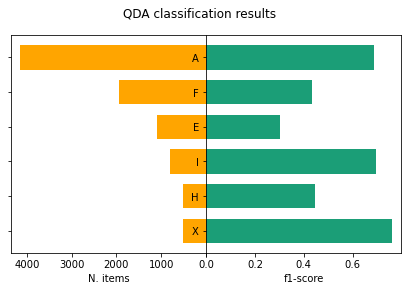

```python
show_f1s(y, y_pred_qda, 'QDA classification results')
```

We now have a baseline accuracy of $0.58$, obtained by fitting a very simple classification model.  
In the following sections, we present algorithms that have more parameters to determine during training, and therefore can, in a sense, be considered "more complex". Our objective is to surpass the current baseline with said models.

```python
from sklearn.preprocessing import FunctionTransformer

qda_final = Pipeline([
    ('column_dropper', FunctionTransformer(lambda X: X.drop(['row number', 'interlinear spacing'], axis='columns'))),
    ('standardizer', std_scaler),
    ('qda', QuadraticDiscriminantAnalysis())
])
# qda_final.fit(X, y); Final fit done at the end
```

# Support Vector Machines

The first model we analyze are Support Vector Machines (SVMs), originally introduced as a binary classification algorithm *(Vapnik, 1995)*. We will later see how to extend such algorithm to a multiclass scenario.  
SVMs generate decision functions that belong to the hypothesis class of *halfspaces*: that is, they attempt to **infer an $n$-dimensional hyperplane of the form $w^Tx+b=0$ which will separate the samples of the two classes within the feature space**. Assuming w.l.g. that the labels take on the values $\pm 1$, the decision function associated to an halfspace can be expressed as:

$$f(x)=\text{sgn}(w^Tx+b)$$

Assuming that a separating hyperplane does exist, given a training set of points $TS=\{(x_i, y_i)\}_{i=1}^N$, we want the algorithm to find $w$ and $b$ such that $\text{sgn}(w^Tx_i+b)=y_i\,\,\forall i$, i.e. **all points are correctly classified**. Such condition can be equivalently formulated as

$$y_i(w^Tx_i+b)>0\quad\forall i$$

This general premise can be applied to all algorithms that generate *halfspace* decision functions. We will now describe how SVMs perform the inference of $w$ and $b$.

## Hard margin SVM

> In the *Hard margin* SVM formulation, we **assume the realizability of the hypothesis**, i.e. there exists an hyperplane that perfectly separates the two classes and for which the aforementioned bound applies. Then a hard margin SVM attempts to find an hyperplane which:
> 1. Results in correct classification of all points
> 2. **Maximizes the distance between the hyperplane itself and the points of any class that are closest to it**. The distance between such point and the hyperplane is called **margin**.

> Recall that the distance of a generic point $x_i$ from a hyperplane $w^Tx+b=0$ can be expressed as

> $$d(x_i)=\frac{\|w^Tx_i-w^Tx\|}{\|w\|}=\frac{\|w^Tx_i+b\|}{\|w\|}=\frac{y_i(w^Tx_i+b)}{\|w\|}$$

> Which becomes $d(x_i)=y_i(w^Tx_i+b)$ with the **additional assumption that $w$ is of unit norm**.  
> Therefore, the measure of the margin can be expressed with $\text{margin}=\min_i d(x_i)=\min_i y_i(w^Tx_i+b)$. The above two points can then be mathematically formulated as a constrained optimization problem:

> $$(w_0, b_0)=\underset{w,\,b\,:\,\|w\|=1}{\operatorname{argmax}}\{\min_i y_i(w^Tx_i+b)\}$$$$\text{s.t.}\quad y_i(w^Tx_i+b)>0\,\;\;\forall i$$

> Now let $\gamma$ be the (still unknown) value of the margin. By setting $w':=w\,/\,\gamma$ and $b':=b\,/\,\gamma$, we can then re-write:
> - the margin as $1\,/\,\|w'\|$
> - the constraint as $y_i(w'^Tx_i+b)\geq 1$

> Which yields the classic formulation of the *hard margin SVM* problem:

> $$(\hat w, \hat b)=\underset{w',\,b'}{\operatorname{argmin}}\frac{1}{2}\|w'\|^2$$$$\text{s.t.}\quad y_i(w'^Tx_i+b')\geq 1\;\;\forall i$$

> where the original $w_0$ and $b_0$ we sought are $w_0=\hat w\,/\,\|\hat w\|$ and $b_0=\hat b\,/\,\|\hat w\|$.

[figure not shown]

This formulation of the SVM problem is unrealistic and not very flexible, since **it relies on the assumption that data points are linearly separable**. Because this is often not the case, this requirment is often relaxed in an alternative formulation of the SVM.

## Soft margin SVM

> The separability assumption is relaxed in the so-called *soft margin* SVM, in which the model is allowed to "make mistakes": **some data points can now cross the the hyperplane that the *hard margin* algorithm would find**, and thus be misclassified. This makes the model less sensible to noise and can dramatically improve performances, so much that this version of the SVM has practically become the standard in real use-cases.

> The relaxation of the correct classification bound is carried out by introducing the so called *slack variables* $\xi_i$ to the constraint.

> $$y_i(w^Tx_i+b)\geq 1-\xi_i\quad\forall i$$

> **Each point is associated to one slack variable which measures how much that point is violating the hard margin rule**. If the point is not crossing its margin, then its slack variable is $0$. In other words, a slack variable can be seen as a contribution of a hinge loss:

> $$\xi_i=\max(0,\;1-y_i(w^Tx_i+b))$$

> Thus, it is possible to formulate the new soft-margin optimization problem as

> $$\min_{w,\,b,\,\xi}\frac{1}{2}\|w\|^2+C\sum_{i=1}^N\xi_i$$$$s.t.\quad y_i(w^Tx_i+b)\geq 1-\xi_i\quad \text{and}\quad \xi_i\geq 0\;\forall i$$

> where $C$ is an hyperparameter which **controls the degree to which the slack variables are taken into account** when minimizing the objective function. For a high $C$, the algorithm will be stricter and will allow fewer mistakes.  
> For $C\rightarrow\infty$, we again obtain the *hard margin* SVM.

[figure not shown]

The *soft margin* SVM is more flexible than its *hard margin* counterpart: it is no chance that the minimization problem above could be seen as a combination of a hinge loss and a L2 regularization term:

$$(\hat w, \hat b)=\arg\min_{w,\,b}\lambda \|w\|^2+\rm R_s^{hinge}(h)$$

where $R_s^{hinge}(h)=\frac{1}{N}\sum_{i=1}^N \max(0,\;1-y_i(w^Tx_i+b))$. Indeed, the goal of a regularization term is to find a good tradeoff between model complexity and classification performance: this has the effect of reducing overfitting, which is exactly what the *soft margin* does with respect to the *hard margin*.

### Hyperparameter tuning

We have now introduced a new hyperparameter $C$, for which we must find the most suitable value. This operation is often called *tuning*. In general, any parameter $\alpha$ of any model $f(x,\alpha)$ can be tuned through cross-validation by finding $\hat\alpha$ which maximizes the score obtained with cross-validation:

$$\hat\alpha=\arg\max_\alpha\;CV(f, \alpha)=\arg\max_\alpha\frac{1}{N}\sum_{i=1}^NG(y_i,f^{-\tau(i)}\left(x, \alpha)\right)$$

## Extending SVM to the multiclass case

So far, SVM was described as a binary classification algorithm; however, our dataset has more than just two classes.  
There are two ways SVM is commonly extended to a multiclass model: we briefly discuss them below. These methods are not specific to SVMs and can theoretically be applied to other halfspace binary classifiers.

### 1. One vs Rest (OvR)

> **For each label $i$, we train a binary classifier** and obtain a decision function $f_i(x)=w^Tx+b$ which must distinguish instances of class $i$ from instances of all other classes.  
> The numerical value of $f_i(x)$ is higher if point $x$ is farther away from the plane, in the $+1$ side: thus, we can interpret the output of $f_i(x)$ as a "certainty measurement" from the classifier that $x$ belongs to class $i$. The natural choice is then to **assign to $x$ the label $i$ whose decision function returns the highest value**:

> $$f_{\text{OvR}}(x)=\arg\max_{i\in Y} f_i(x)$$

### 2. One vs One (OvO)

> We train a classifier **for each possible couple of classes**: we obtain $f_i(x)$ which is supposed to distinguish between those two classes only. To classify point $x$, we pass it through all classifiers. We then perform a **majority vote**: the class that gets predicted the most is assigned to $x$.

In scikit-learn, the class `LinearSVC` implements a *One vs Rest* strategy for multiclass classification, while the class `SVC` implements a *One vs One* strategy. We will use both in our validation procedure and compare their performance.  
Further differences between `LinearSVC` and `SVC` involve kernelization options, which will be discussed in the following section.

```python
from sklearn.svm import LinearSVC
from sklearn.svm import SVC

lin_svc = LinearSVC(loss='hinge', random_state=random_state, max_iter=100000, verbose=1) # One-vs-Rest
svc = SVC(kernel='linear', random_state=random_state, verbose=True) # One-vs-One

svc_ovr_pipe = Pipeline([
    ('standardizer', StandardScaler()),
    ('svm', lin_svc)
])

svc_ovo_pipe = Pipeline([
    ('standardizer', StandardScaler()),
    ('svm', svc)
])
```

```python
from sklearn.model_selection import GridSearchCV

param_grid = {
    'svm__C': [0.01, 0.1, 1, 10]
}

svc_ovr_cv = GridSearchCV(
    svc_ovr_pipe,
    param_grid=param_grid,
    scoring='accuracy',
    n_jobs=-1,
    cv=5,
    verbose=1,
)

svc_ovo_cv = GridSearchCV(
    svc_ovo_pipe,
    param_grid=param_grid,
    scoring='accuracy',
    n_jobs=-1,
    cv=5,
    verbose=1
)
```

```python
ovr_svc_path = 'res/ovr_svc.csv'

if exists(ovr_svc_path):
    ovr_res = pd.read_csv(ovr_svc_path)
    print('Read result from memory')
else:
    svc_ovr_cv.fit(X, y)
    ovr_res = pd.DataFrame(svc_ovr_cv.cv_results_)
    ovr_res.to_csv(ovr_svc_path, index=False)
```

```
Read result from memory
```

```python
def gridsearch_or_load(gs, X, y, path):
    """
    Check if the given path exixts. If so, read result file of the gridsearch from memory.
    Otherwise, run the gridsearch and save the results in memory.

    Args:
        gs: sk-learn gridsearch instance
        X: training data
        y: target
        path: path of the result file

    Returns:
        gs estimator passed
        result pandas dataframe
    """
    if exists(path):
        res = pd.read_csv(path)
        print('Read result from memory')
    else:
        print('Launching gridsearch...')
        gs.fit(X, y)
        res = pd.DataFrame(gs.cv_results_)
        res.to_csv(path, index=False)
        print(f'Results stored at {path}')

    return gs, res
```

```python
ovo_svc_path = 'res/ovo_svc.csv'
svc_ovo_cv, ovo_res = gridsearch_or_load(svc_ovo_cv, X, y, ovo_svc_path)
```

```
Read result from memory
```

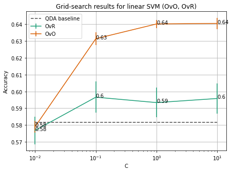

```python
cv_svm_fig, cv_svm_ax = plt.subplots(figsize=(7,5))
cv_svm_ax.set_xscale('log')
cv_svm_ax.set_title('Grid-search results for linear SVM (OvO, OvR)')
cv_svm_ax.grid(True)

cv_svm_ax.errorbar(x=ovr_res['param_svm__C'], y=ovr_res['mean_test_score'], yerr=ovr_res['std_test_score'], label='OvR')
cv_svm_ax.errorbar(x=ovo_res['param_svm__C'], y=ovo_res['mean_test_score'], yerr=ovo_res['std_test_score'], label='OvO')
cv_svm_ax.hlines(y=baseline, xmin=ovo_res['param_svm__C'].min(), xmax=ovo_res['param_svm__C'].max(), color='#4a4a4a', label='QDA baseline', linestyles='dashed')

for xp, yp, score in zip(ovr_res['param_svm__C'], ovr_res['mean_test_score'], ovr_res['mean_test_score']):
    cv_svm_ax.annotate(text=round(score, 2), xy=(xp,yp))
for xp, yp, score in zip(ovo_res['param_svm__C'], ovo_res['mean_test_score'], ovo_res['mean_test_score']):
    cv_svm_ax.annotate(text=round(score, 2), xy=(xp,yp))

cv_svm_ax.legend()
cv_svm_ax.set_xlabel('C')
cv_svm_ax.set_ylabel('Accuracy');
```

Neither of the strategies seem to bring critical improvements over the baselines; however, the *One vs One* seems to perform slightly better. The best values found for $C$ are $1$ and $10$, with almost no difference.

After having found the best model through cross-validation, it is necessary to **re-fit it to the whole dataset in order to harness all available information**. The `GridSearchCV` class automatically picks the most performing set of hyperparameters and executes the final re-fit automatically.

```python
# Code commented and replaced with static jpg image for faster rendering
# svc_ovo_pipe['svm'].set_params(**{'C':1})
# svc_ovr_pipe['svm'].set_params(**{'C':1})

# svc_ovo_pipe.fit(num_X, num_y)
# svc_ovr_pipe.fit(num_X, num_y);
```

```python
# figsvmlin, axsvmlin = plt.subplots(1, 2,figsize=(13, 5.1))
# axsvmlin[0].set_title('SVM OvR decision boundary')
# axsvmlin[1].set_title('SVM OvO decision boundary')
# dec_bound(svc_ovr_pipe, num_X, num_y, ax=axsvmlin[0], columns=X.columns, feature_index=(0,8), ylim=(0,1), filler_val=0.5, filler_range=0.7)
# dec_bound(svc_ovo_pipe, num_X, num_y, ax=axsvmlin[1], columns=X.columns, feature_index=(0,8), ylim=(0,1), filler_val=0.5, filler_range=0.7)
```

[figure not shown]

## Kernelizing the SVM

As previously mentioned, an SVM algorithm results in a decision function of the form of an *halfspace*.  
This can be particularly effective for high-dimensional spaces, in which points tend to be more sparse, and it is therefore somewhat "easier" to find an hyperplane that separates them.

However, the data might be distributed in such a way that it is impossible to find a linear separation between classes. One possible solution is to **project the data $X$ into a higher dimensional space in which we hope it is possible to find a linear separation between classes**.  
This strategy is not exclusive to SVM: in principle, it can be applied to any dataset, regardless of the algorithm. One general procedure for that would be:

1. Choose some mapping function $\phi : \mathcal{X}\rightarrow \mathcal{F}$, where $\mathcal{X}$ is the original space and $\mathcal{F}$ is the new feature space of higher dimension. One possible example could be $\phi : x\mapsto(x, x^2)$
2. Given a training set $S=\{(x_i,y_i)\}_i$, compute the mapped dataset $\hat S=\{(\phi(x_i),y_i)\}_i$
3. Train a linear model over $\hat S$, to obtain a classification function $f$. At test time, for point $x$, compute $f(\phi(x))$

However, this procedure may be **computationally unfeasible**: if the starting data is already high-dimensional, then projecting it into another space might be too costly in terms of memory, time, or both.  
Nevertheless, for certain algorithms, it is possible to circumvent this issue by making use of the so-called *kernel trick*. The SVM is one of those algorithms.

[figure not shown]

> **A kernel function represents an inner product in a higher-dimensional space**. It is a way to implicitly project points to higher dimensions without actually computing the mapping.

> $$K(x,x'):=\langle\phi(x),\phi(x')\rangle$$

> This means that, if it is possible to express a certain algorithm only in terms of inner products $\langle x,x'\rangle$, then we can implicitly project every processed point by substituting $\langle x,x'\rangle\rightarrow K(x,x')$.  
> A formulation of the SVM which only depends on inner products can be found by computing the dual optimization problem. This is achieved by **taking the Lagrangian of the original objective function and setting its gradient to $0$**. Some algebric manipulation then leads to the following forumlation of the dual problem:

> $$\min_{\alpha}\frac{1}{2}\sum_{i=1}^N\sum_{j=1}^N y_i y_j \alpha_i \alpha_j \langle x_i, x_j\rangle-\sum_{i=1}^N \alpha_i$$$$s.t.\quad 0\leq\alpha_i\leq C\;\;\forall i\quad \text{and}\quad\sum_{i=1}^N y_i\alpha_i=0$$

> where $\alpha_i$ are the Lagrange multipliers associated to the first contraint of the *soft margin* primal. It can also be shown that the original (and optimal) $\hat w$ and $\hat b$ term can be expressed in terms of Lagrange multipliers:

> $$\hat w=\sum_{i=1}^N\alpha_i y_i x_i\quad\quad\hat b=y_{sv}-\langle\hat w,x_{sv}\rangle$$

> where $x_{sv}$ and $y_{sv}$ are any support vector and its associated label, respectively (more about support vectors shortly).

Notably, one could also prove the following:

- for correctly classified vectors that lie outside the margin (i.e. $x_i$ for which $y_i(\langle \hat w,x_i\rangle+\hat b)>1$) $\;\Longrightarrow\;\alpha_i = 0$
- for vectors that lie exactly on the margin (i.e. $x_i$ for which $y_i(\langle \hat w,x_i\rangle+\hat b)=1$) $\;\Longrightarrow\;0<\alpha_i < C$
- for vectors that lie within the margin and for misclassified vectors (i.e. $x_i$ for which $y_i(\langle \hat w,x_i\rangle+\hat b)<1$) $\;\Longrightarrow\;\alpha_i = C$

Therefore, only misclassfied data points or points that lie exactly on the margin give an actual contribution to the sum $\hat w=\sum_{i=1}^N\alpha_i y_i x_i$. Hence the name of the algorithm: **the parameter $w$ of the optimal separating hyperplane is given by a sum of vectors that "support" the margin**.

> Back to kernels: we can now express the whole SVM algorithm only in terms of inner products between data points.  
> The ojbective function to minimize becomes:

> $$\min_{\alpha}\frac{1}{2}\sum_{i=1}^N\sum_{j=1}^N y_i y_j \alpha_i \alpha_j K(x_i, x_j)-\sum_{i=1}^N \alpha_i$$

> While the decision function can now be expressed as: $$f(x)=\langle \hat w,x\rangle+\hat b=\langle\sum_{i=1}^N\alpha_i y_i x_i, x\rangle+\hat b=\sum_{i=1}^N\alpha_i y_i\langle x_i,x\rangle+\hat b$$

> in which we can again substitute the kernel

> $$f(x)=\sum_{i=1}^N\alpha_i y_i K(x_i,x)+\hat b$$

Popular kernel choices include:

- **radial basis function (RBF)** kernel: $K(x, x')=\exp(\gamma \|x-x'\|^2)$
- **polynomial** kernel: $K(x,x')=(\gamma \langle x, x'\rangle + r)^d$
- **sigmoid** kernel: $K(x,x')=\tanh(\gamma \langle x,x'\rangle + r)$

Notice that the above are kernel functions and **not** the mappings $\phi(\cdot)$ themselves. However, we have a way to know these undoubtedly correspond to some underlying mapping function thanks to *Mercer's theorem*.

> **Mercer's theorem.** Let $K:\mathcal{X}\,\text{x}\,\mathcal{X}\longrightarrow\mathbb{R}$ be a **symmetric** and **positive semi-definite** function. Then $K$ implements an inner product $\langle\phi(x),\phi(x')\rangle$ in some hilbert space.  
> A kernel function is said to be positive semi-definite if either of the following (equivalent) condition is true:
> - $K$ is square-integrable (or "$L_2$") in $\mathcal{X}\,\text{x}\,\mathcal{X}$ and satisfies $$\int_{\mathcal{X}\,\text{x}\,\mathcal{X}}K(x,x')f(x)f(x')dxdx'\geq 0\quad\forall f\in L_2(\mathcal{X})$$
> - $K$'s *Graham matrix* $G_{ij}=K(x_i,x_j)$ is positive semi-definite $\forall x_1\dots x_m$ (i.e. $x^TGx\geq 0\;\;\forall x$).

In our analysis, we will experiment with all presented kernels. The RBF kernel introduces a new parameter to tune, $\gamma$; the polynomial kernel introduces two more, $d$ (the polynomial's degree) and $r$ (the intercept). Beacuse our computational resources are limited, we will only tune $\gamma$ and $d$ and leave $r$ at default setting.

```python
rbf_svc = SVC(kernel='rbf', random_state=random_state, verbose=True) # RBF kernel
poly_svc = SVC(kernel='poly', random_state=random_state, verbose=True) # Polynomial kernel
sigm_svc = SVC(kernel='sigmoid', random_state=random_state, verbose=True) # Polynomial kernel

rbf_params = {
    'svc__gamma': [0.01, 0.1, 1, 10],
    'svc__C': [0.01, 0.1, 1, 10],
}

poly_params = {
    'svc__gamma': [0.01, 0.1, 1],
    'svc__C': [0.01, 0.1, 1],
    'svc__degree': [2, 3]
}
```

```python
rbf_svc_pipe = Pipeline([ # RBF Pipeline
    ('standardizer', StandardScaler()),
    ('svc', rbf_svc)
])

poly_svc_pipe = Pipeline([ # Poly pipeline
    ('standardizer', StandardScaler()),
    ('svc', poly_svc)
])

sigm_svc_pipe = Pipeline([ # Sigmoid pipeline
    ('standardizer', StandardScaler()),
    ('svc', sigm_svc)
])
```

```python
svc_rbf_cv = GridSearchCV( # RBF gridsearch
    rbf_svc_pipe,
    param_grid=rbf_params,
    scoring='accuracy',
    n_jobs=-1,
    cv=5,
    verbose=1,
)

svc_poly_cv = GridSearchCV( # Poly gridsearch
    poly_svc_pipe,
    param_grid=poly_params,
    scoring='accuracy',
    n_jobs=-1,
    cv=5,
    verbose=2,
)

svc_sigm_cv = GridSearchCV( # Sigmoid gridsearch
    sigm_svc_pipe,
    param_grid=rbf_params,
    scoring='accuracy',
    n_jobs=-1,
    cv=5,
    verbose=2,
)
```

```python
rbf_svc_path = 'res/rbf_svc.csv'
svc_rbf_cv, rbf_res = gridsearch_or_load(svc_rbf_cv, X, y, rbf_svc_path)
```

```
Read result from memory
```

```python
poly_svc_path = 'res/poly_svc.csv'
svc_poly_cv, poly_res = gridsearch_or_load(svc_poly_cv, X, y, poly_svc_path)
```

```
Read result from memory
```

```python
sigm_svc_path = 'res/sigm_svc.csv'
svc_sigm_cv, sigm_res = gridsearch_or_load(svc_sigm_cv, X, y, sigm_svc_path)
```

```
Read result from memory
```

```python
def one_result_line_svc(res, label, title, ax):
    """
    Plots an errorbar plot to the given axis using the data contained in res. The output is assume to be the one of an SVM and is plotted across the C values.

    Params:
        res (pandas DataFrame): result of a GridSearchCV instance
        label (str): label to show in the legend
        title (str): title of the axis
        ax (plt axis): axis to plot on
    """
    ax.set_xscale('log')
    ax.set_title(title)
    ax.grid(True)

    ax.errorbar(x=res['param_svc__C'], y=res['mean_test_score'], yerr=res['std_test_score'], label=label)

    # Annotating the maximum value (assuming there is one. Let's be serious, there won't be two)
    max_record = res.loc[res['mean_test_score'].idxmax()]
    xp = max_record['param_svc__C']
    yp = max_record['mean_test_score']
    text = round(max_record['mean_test_score'], 2)
    ax.annotate(text=text, xy=(xp,yp))

    ax.legend()
    ax.set_xlabel('C')
```

```python
def plot_over_gamma_svc(res, title, ax):
    """
    Construct a result plot of a SVC gridsearch, with C on X axis. Plot one line for each value of gamma.

    Params:
        res (pandas DataFrame): result of a GridSearchCV instance
        label (str): label to show in the legend
        title (str): title of the axis
        ax (plt axis): axis to plot on
    """
    for gamma, data in res.groupby('param_svc__gamma'):
        one_result_line_svc(data, f'gamma={gamma}', title, ax)
```

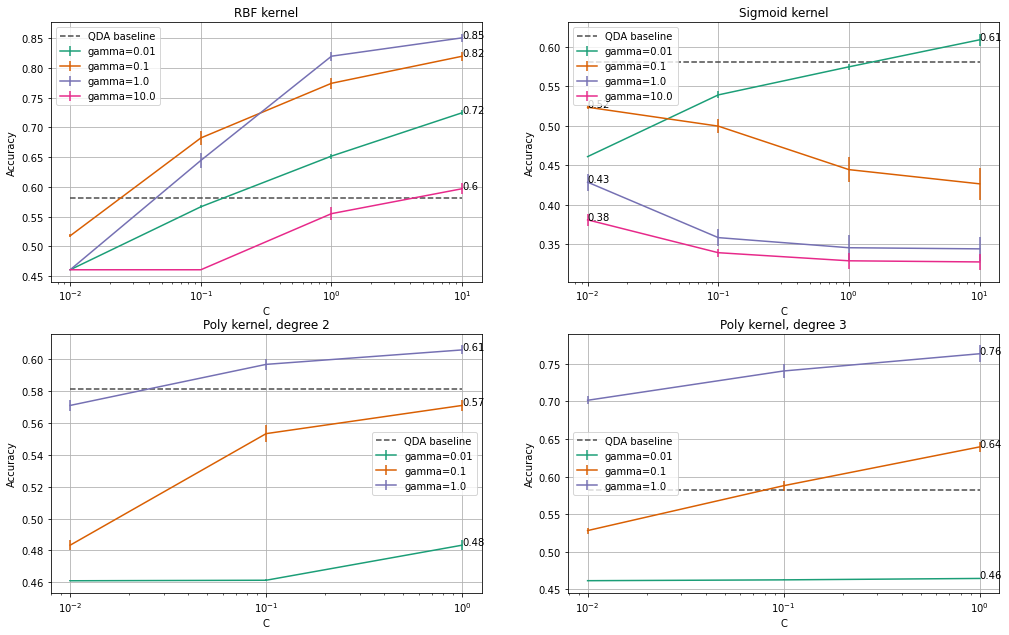

```python
ker_svm_fig, ker_svm_ax = plt.subplots(2,2, figsize=(17,10.5)) # Inizialize figure

# Plot baseline line
for ax in ker_svm_ax[0]:
    ax.hlines(y=baseline, xmin=rbf_res['param_svc__C'].min(), xmax=rbf_res['param_svc__C'].max(), color='#4a4a4a', label='QDA baseline', linestyles='dashed')
    ax.set_ylabel('Accuracy');

for ax in ker_svm_ax[1]:
    ax.hlines(y=baseline, xmin=poly_res['param_svc__C'].min(), xmax=poly_res['param_svc__C'].max(), color='#4a4a4a', label='QDA baseline', linestyles='dashed')
    ax.set_ylabel('Accuracy');

plot_over_gamma_svc(rbf_res, 'RBF kernel', ker_svm_ax[0][0])
plot_over_gamma_svc(sigm_res, 'Sigmoid kernel', ker_svm_ax[0][1])
plot_over_gamma_svc(poly_res[poly_res['param_svc__degree']==2], 'Poly kernel, degree 2', ker_svm_ax[1][0])
plot_over_gamma_svc(poly_res[poly_res['param_svc__degree']==3], 'Poly kernel, degree 3', ker_svm_ax[1][1])
```

We conclude that the RBF kernel is the most effective, obtaining a dramatic improvement over the linear kernel. The new best score is $0.85$ accuracy, with RBF kernel, $C=10$ and $\gamma=1$.

```python
svm_best_params = literal_eval(rbf_res.loc[rbf_res['rank_test_score'].idxmin()]['params'])
svm_final = rbf_svc_pipe.set_params(**svm_best_params)
# svm_final.fit(X, y); Not needed anymore, final fit is done at the end
```

```python
# Commented and replaced with static jpg image for faster rendering
# rbf_svc_pipe['svc'].set_params(**{'C':1})
# poly_svc_pipe['svc'].set_params(**{'C':1})
# sigm_svc_pipe['svc'].set_params(**{'C':1})

# rbf_svc_pipe.fit(num_X, num_y)
# poly_svc_pipe.fit(num_X, num_y)
# sigm_svc_pipe.fit(num_X, num_y);
```

```python
# figsvm, axsvm = plt.subplots(1, 3, figsize=(20, 5.1))
# axsvm[0].set_title('RBF kernel decision boundary')
# axsvm[1].set_title('Poly kernel decision boundary')
# axsvm[2].set_title('Tanh kernel decision boundary')
# dec_bound(rbf_svc_pipe, num_X, num_y, ax=axsvm[0], columns=X.columns, feature_index=(0,8), ylim=(0,1), filler_val=0.5, filler_range=0.7)
# dec_bound(poly_svc_pipe, num_X, num_y, ax=axsvm[1], columns=X.columns, feature_index=(0,8), ylim=(0,1), filler_val=0.5, filler_range=0.7)
# dec_bound(sigm_svc_pipe, num_X, num_y, ax=axsvm[2], columns=X.columns, feature_index=(0,8), ylim=(0,1), filler_val=0.5, filler_range=0.7)
```

[figure not shown]

# Logistic regression

We had little succcess in trying to model the class distribution of the dataset with a linear kernel SVM. We now move towards a completely different kind of linear model and see wether this brings us to the same conclusion.  
Despite its name, the **logistic regression** model is a **classification technique**. The name "regression" might stem from the fact that this algorithm can be described as a part of the wider framework of *Genralized linear models*. We firstly describe the mathematical formulation of logistic regression for binary classification problems; we then give a brief intuition on how this technique can be extended to the multiclass case.

> In a *Generalized linear model*, **we model $\mathbb{P}(y|x,w)$ as some distribution belonging to the *exponential family***. According to the kind of response $y$ we can get, we choose a suitable distribution for $\mathbb{P}(y|x,w)$.  
> Such choice **affects the possible values taken on by $\mathbb{E}(y)$, which is what we primarily try to describe in a generalized linear model**. The most general form of a generalized linear model is:

> $$\mathbb{E}(y)=g^{-1}\left(Xw\right)$$

> where $g^{-1}$ is the inverse of the so-called **link function**. In short, we are trying to mathematically model the expected value of the response with a linear combination of predictors $Xw$ passed through a suitable function $g^{-1}$. The role of such function is primarily to map the image of $Xw$ (which spans through all the real numbers) to the domain of $\mathbb{E}(y)$ .

> In a logistic regression model, we assume that the **response variable is binary and behaves like a Bernoulli random variable with parameter $p$**. In other words, $y_i$ can either be $1$ or $0$ with probability $p_i$ and $1-p_i$ respectively, and $\mathbb{P}(y_i|p_i)=p_i^{y_i}(1-p_i)^{1-y_i}$. Consequently, $\mathbb{E}(y_i)=p_i\in [0,1]$. **The inverse of the link function must be of the kind $g^{-1}:(-\infty, +\infty)\longrightarrow [0,1]$**. One common choice, which can be motivated by theoretical aspects not discussed here, is the "**logistic function**":

> $$\mathbb{E}(y_i)=p_i=g^{-1}\left(w^Tx_i\right)=\frac{e^{w^Tx_i}}{1+e^{w^Tx_i}}$$

> which implies that the link function is the **logit** function $g(p)=\ln (\frac{p}{1-p})=w^Tx_i$. Which means the probability mass of $y$ is modeled as

> $$P(y_i|x_i,w)=\left(\frac{e^{w^Tx_i}}{1+e^{w^Tx_i}}\right)^{y_i}\left(1-\frac{e^{w^Tx_i}}{1+e^{w^Tx_i}}\right)^{1-y_i}$$

> The parameter $w$ can then be estimated by **maximum likelihood**. However, the equation $\frac{d}{dw}L\left(w|X,y\right)=0$ does not have a closed form solution, so an optimal value for $w$ must be computed by means of numerical optimization techniques.  
> Below is a graphical representation of the logistic function.

[figure not shown]

In simpler terms, logistic regression models the log-odds of sample $y_i$ belonging to class $1$ as a linear combination of predictors $x_i^Tw$.

As previously mentioned, the method described above is valid for binary classification problems. In order to **expand logistic regression to the multiclass scenario**, the following options can be considered:

- choose another **suitable link function so that it adapts to multiple possible values of $y$.** The details are not discussed here, but the idea is to use $K-1$ logits as links, thus estimating $(p+1)\times(K-1)$ parameters (where $p$ is the number of predictors and $K$ the number of classes). This results in a density of $P(y_i=k|\mathbf{x}_i,\mathbf{w}_k)$ that resembles a softmax function.
- use the *One vs Rest* or *One vs One* approach as previously described.

The scikit-learn library offers both implementations. We are going to employ the former, as it is the default setting for multiclass problems.

```python
from sklearn.linear_model import LogisticRegression

lr = Pipeline([('scaler', StandardScaler()), ('lr', LogisticRegression(penalty='none'))])
y_lr = cross_val_predict(lr, X, y)
lr_acc = round(accuracy_score(y, y_lr), 3)
print(f'Initial logistic regression accuracy (cross-validation): {lr_acc}')
print('Other stats:')
print(classification_report(y, y_lr))
```

```
Initial logistic regression accuracy (cross-validation): 0.63
Other stats:
              precision    recall  f1-score   support

           A       0.60      0.94      0.73      4156
           E       0.59      0.31      0.41      1088
           F       0.40      0.08      0.13      1946
           H       0.62      0.30      0.41       516
           I       0.94      0.91      0.92       802
           X       0.82      0.79      0.81       515

    accuracy                           0.63      9023
   macro avg       0.66      0.56      0.57      9023
weighted avg       0.60      0.63      0.56      9023
```

With no special preprocessing, linear regression does not have satisfactory results: we obtain a $63\%$ accuracy, a very similar score to the linear kernel SVM. We can try to inspect the f1 scores of each individual class as an attempt to understand what is causing the model to fail.

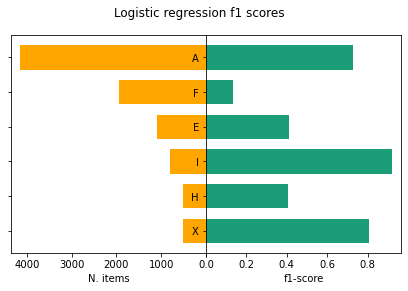

```python
show_f1s(y, y_lr, 'Logistic regression f1 scores')
```

```python
# Both commented for faster rendering
# lr.fit(num_X, num_y);
```

```python
# figlr, axlr = plt.subplots(figsize=(7.1, 5.1))
# axlr.set_title('Logistic regression decision boundary')
# dec_bound(lr, num_X, num_y, ax=axlr, columns=X.columns, feature_index=(0,8), ylim=(0,2), filler_val=0.5, filler_range=0.7)
```

[figure not shown]

While classes `A`, `I` and `X` are very well recognized by the model (despite `X` being the least numerous), **labels `F`, `E` and `H` seem harder to classify**. One possible targeted countermeasure would be to try to **make these classes more recognizable**. We adopt a strategy based on **oversampling**: we will try to generate synthetic examples of classes `F`, `E` and `H` to make them more numerous, hoping that this will assist the model in better recognizing them. Of course, to carry out such a task, we need an oversampling algorithm.

## Synthetic Minority Over-sampling Technique (SMOTE)

> *SMOTE* is an oversamplig technique proposed in *(Chawla, 2002)* to tackle the problem of class imbalance in a training dataset for a classification task. It essentially consists in **tracing "hyper-segments" between points of a minority class, then sample new synthetic points along those segments**. The following pseudo-code illustrates this mechanic more in depth:

> ```
> SMOTE(D, k, N):
>     // D: unbalanced dataset, k: number of neighbors, N: final size of minority class
>     while the minority class has fewer than N points do:
>         A <- random point within the minority class
>         B <- random point within the k nearest neighbors of A of its same class
>         for attr in each attribute of the feature space:
>             λ <- random number ∈ (0,1)
>             new_point[attr] <- A[attr] + (B[attr]-A[attr])*λ
>         add new_point in minority class
> ```

> This algorithm can be used to artificially incerase the instances of a certain class to some number $N$ until the desired balance is achieved.

[figure not shown]

We will use SMOTE on classes `F`, `E` and `H` to make them more numerous: hopefully, this will make the model more aware of their presence and will ease their classification.

### Cross validation and SMOTE

When using cross validation, one must make sure that **only the training folds are oversampled, and not the validation fold**. This means that it will be necessary to run SMOTE $k$ times, where $k$ is the number of folds.  
It is equally important to make sure that **the sampling for the partitioning is stratified**, so that the original distribution of the classes is kept the same in all folds. This is a general rule which holds even when not applying SMOTE.

In the following code, we address both of those matters. We attempt to find the best oversampling proportions by trial and error; the final sampling strategy can be found in the code.

```python
from imblearn.over_sampling import SMOTE
from imblearn.over_sampling import SVMSMOTE
from sklearn.model_selection import StratifiedKFold

n_folds = 5
shrink = (n_folds-1)/n_folds

sampling_strategy = {
    'F': int(3000*shrink),
    'E': int(2000*shrink),
    'H': int(1000*shrink),
}

print(f'Sampling strategy: {sampling_strategy}')


smote = SMOTE(sampling_strategy=sampling_strategy, k_neighbors=10, random_state=random_state)
```

```
Sampling strategy: {'F': 2400, 'E': 1600, 'H': 800}
```

```python
def smote_cross_val(clf, smote, X, y, cv=5):
    """
    Performs cross-validation by using SMOTE.

    Params:
        clf: sklearn classifier
        smote: imblearn instance of a smote class
        X: traning data, not oversampled
        y: labels, not oversampled
        cv: number of folds

    Returns:
        statistics of f1 and accuracy for each fold aggregated as a pd DataFrame
    """
    skfold = StratifiedKFold(n_splits=n_folds)
    stats = pd.DataFrame(columns=list(y.cat.categories)+['accuracy'])

    for train_index, val_index in skfold.split(X, y):
        X_train, X_val = X.iloc[train_index], X.iloc[val_index]
        y_train, y_val = y.iloc[train_index], y.iloc[val_index]

        # Resample only the current training data with smote
        X_train_r, y_train_r = smote.fit_resample(X_train, y_train)

        clf.fit(X_train_r, y_train_r)
        y_pred = clf.predict(X_val)

        f1s = f1_score(y_val, y_pred, average=None)

        new_row = {label: f1 for label, f1 in zip(y.cat.categories, f1s)}
        new_row['accuracy'] = accuracy_score(y_val, y_pred)
        stats = stats.append(new_row, ignore_index=True)

    return stats
```

```python
smote_res = smote_cross_val(lr, smote, X, y, cv=n_folds)
```

```python
print(f'Mean results of {n_folds}-fold cross validation after SMOTE oversampling (f1 + accuracy):')
print(smote_res.mean())
```

```
Mean results of 5-fold cross validation after SMOTE oversampling (f1 + accuracy):
A           0.723748
E           0.520976
F           0.399001
H           0.433140
I           0.923180
X           0.801138
accuracy    0.643801
dtype: float64
```

While we do see some slight improvement on the f1-scores of classes `F`, `E` and `H`, it seems that it is not enough to increase the overall accuracy by a substantial amount (we gain only $1%$ more).

We therefore recap some existing variations on the original SMOTE algorithm, to see whether some slightly more advanced oversampling technique can be helpful.

### SVM-SMOTE

Proposed in *(Nguyen, 2009)*, this technique combines an SVM classifier (possibly kernelized) with SMOTE oversampling. We first run the SVM algorithm on the original (i.e. not oversampled) dataset and **obtain some support vectors**. The idea is that, because support vectors are those that are **closest to the boundaries between classes**, they may aid in distinguishing class clusters.  
Therefore, for the classes we intend to oversample, we select the support vectors whose $k$-nearest neighbors are mostly from the same class. **We then run SMOTE on those points**.  
This should results in a more clearly outlined border between classes, which could in turn ease the classification task for the model.

Notice that distances between points be computed in kernel space with the formula

$$d\left(x,x'\right)=\sqrt{K\left(x',x'\right)+K\left(x,x\right)-2K\left(x, x'\right)}$$

[figure not shown]

### K-means SMOTE

*(Last, 2017)* proposes a techinque based on **running a K-means algorithm on the data prior to oversampling**. Among the K found clusters, **we then pick the ones whose samples mostly come from the minority class**, and only run SMOTE within those. This should avoid tracing hypersegments which overlap with the bigger clusters of majority samples.

### ADASYN

For each point in the minority class, we compute the $k$-nearest neighbor. We then compute **the fraction of samples from the majority class amongst those $k$ neighbors**: the oversampling will be performed more heavily for points whose neighbors are mostly from the majority class. Hence the name ADASYN: *adaptive synthetic sampling (Haibo, 2009)*.

Let us recall that, in the previous section, we have established that an SVM with an RBF kernel works rather well on this dataset; moreover, we already have run a grid search with said classifier and obtained the best parameters for the task. Therefore, we make an **attempt at using SVM-SMOTE** to see if that brings any additional improvement over traditional SMOTE. The SVM we use for the initial step is run with the best hyperparameters found at the end of the previous section.

```python
svm_smote = SVMSMOTE(sampling_strategy=sampling_strategy, k_neighbors=10, random_state=random_state,
                svm_estimator=SVC(kernel='rbf', C=10, gamma=1) # Using best parameters
                )
```

```python
svmsmote_res = smote_cross_val(lr, svm_smote, X, y, cv=n_folds)
```

```python
print(f'Mean results of {n_folds}-fold cross validation after SMOTE oversampling:')
print(svmsmote_res.mean())
```

```
Mean results of 5-fold cross validation after SMOTE oversampling:
A           0.725046
E           0.512353
F           0.381331
H           0.432009
I           0.925747
X           0.808829
accuracy    0.642249
dtype: float64
```

Our intuition was not correct: **SVM-SMOTE performs almost exactly like its original counterpart**. We turn away from oversampling and make one further attempt at improving the logistic regression performance.

## Akaike information criterion (AIC)

We want to verify is it is helpful to remove some attribute which might mislead the model. To do so, we use a model selection technique known as AIC.

> **Akaike information criterion (AIC)** *(Akaike, 1974)* can be used to assess the validity of models which use a *maximum likelihood* approach to infer their parameters from the available data. Let $k$ be the number of predictors used by the model and $L_{\text{MLE}}$ be the likelihood of its parameters. Then the AIC is computed as

> $$AIC = 2k-2\ln L_{\text{MLE}}$$

> This value does not have a true meaning on its own: it only makes sense when compared to the AIC of other models. The idea is that AIC will give information about the following aspects:
> - goodness of fit of the model (indicated by a high likelihood)
> - simplicity of the model (indicated by a small number of predictors): a simpler model is to be preferred over a complex one

> **The model with the smallest AIC is considered to have the best tradeoff between the two above properties**.

In our case, we will **iteratively remove a single predictor from the dataset out of the $N=9$ available, creating $N$ nested logistic regression models with $N-1$ predictors each**. We will compute the AIC values for all of them and compare the results. In addition, we compute the AIC for the full logistic regression we previously used, and also compare that to the rest of the models.

```python
from statsmodels.discrete.discrete_model import MNLogit
from statsmodels.tools.eval_measures import aic

# We need to manually insert a column of 1's
Xc = X.copy()
Xc.insert(0, 'ones', np.ones(len(X), dtype=int))
```

```python
full_model_name = 'NO_COLUMN'
aic_values = pd.Series(index = [full_model_name] + list(Xc.columns), dtype=float)

for column in [None] + list(Xc.columns):
    # Remove column (if not none)
    if column:
        X_small = Xc.drop(column, axis='columns')
        print(f'Fitting model without predictor {column}')
    else:
        X_small = Xc.copy()
        column = full_model_name
        print(f'Fitting full model')

    # Instantiate and fit the model on the reduce dataset
    mnlogit_small_mod = MNLogit(y, X_small)
    with io.capture_output() as captured:
        mnlogit_small_res =mnlogit_small_mod.fit()
    llik_small = mnlogit_small_res.llf

    current_aic = aic(llik_small, X_small.shape[0], X_small.shape[1])
    aic_values[column] = current_aic
```

```
Fitting full model
Fitting model without predictor ones
Fitting model without predictor intercolumnar distance
Fitting model without predictor upper margin
Fitting model without predictor lower margin
Fitting model without predictor exploitation
Fitting model without predictor row number
Fitting model without predictor modular ratio
Fitting model without predictor interlinear spacing
Fitting model without predictor weight
Fitting model without predictor peak number
```

```python
to_remove = aic_values.idxmin()
print(f'Column to remove to obtain lowest AIC: {to_remove}')
print(aic_values)
```

```
Column to remove to obtain lowest AIC: NO_COLUMN
NO_COLUMN                 17821.508374
ones                      25639.295943
intercolumnar distance    18339.038201
upper margin              18021.698057
lower margin              18055.857260
exploitation              18311.539344
row number                18651.410634
modular ratio             18369.440618
interlinear spacing       18041.476392
weight                    18543.429373
peak number               20252.396574
dtype: float64
```

Unfortunately, the best model in terms of AIC is the full model, which we have already used. It seems that a logistic regression algorithm is just not fit for this task, and we stop at a validation accuracy of about $64\%$. To at least get some insight on which attributes appear to be the most important from the standpoint of a logistic regression, we visually inspect each AIC value.

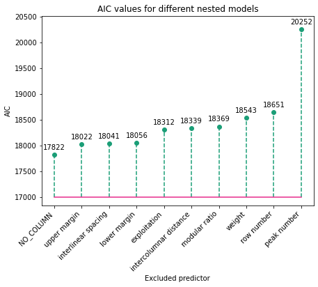

```python
aic_fig, aic_ax = plt.subplots(figsize=(7, 5))
aic_plot = aic_values.drop('ones').sort_values()
aic_ax.stem(np.arange(len(aic_plot)), aic_plot, bottom=17000, linefmt='--')
aic_ax.set_xticks(np.arange(len(aic_plot)))
aic_ax.set_xticklabels(aic_plot.index, rotation=45, ha='right')
# plt.xticks(rotation=60);

for xp, yp in enumerate(aic_plot):
    aic_ax.annotate(round(yp), xy=(xp,yp), xytext=(xp-0.4,yp+100))

aic_ax.set_title('AIC values for different nested models')
aic_ax.set_xlabel('Excluded predictor')
aic_ax.set_ylabel('AIC')
aic_ax.set_ylim(top=aic_ax.get_ylim()[1]+100);
```

The label on the x-axis indicates the attribute which, when removed, would achieve the shown AIC. Thus, from left to right, it is possible to read the predictors that we would have to remove first if we were to do a feature selection operation from an AIC standpoint. In a very abstract sense, we can intrepret the attributes as being sorted by "feature importance", the rightmost one being the most important.

In conclusion, we choose to use the SMOTEed logistic regression for the final test. Normal SMOTE and SVM-SMOTE yielded virtually the same result. We therefore choose the first one, mainly for ease of computation.

```python
# final_sampling_strategy = {
#     'F': 3000,
#     'E': 2000,
#     'H': 1000
# }

# print(f'Final sampling strategy: {final_sampling_strategy}')

# final_smote = SMOTE(sampling_strategy=final_sampling_strategy, k_neighbors=10, random_state=random_state)

# X_whole_res, y_whole_res = final_smote.fit_resample(X, y)

# final_lr.fit(X_whole_res, y_whole_res);
```

```python
final_lr = Pipeline([('scaler', StandardScaler()), ('lr', LogisticRegression(penalty='none'))])
final_smote_params_lr = {
    'sampling_strategy': {
        'F': 3000,
        'E': 2000,
        'H': 1000
    },
    'k_neighbors': 10,
    'random_state': random_state
}
```

# Ridge Classifier / Least Squares SVM

We engage in one last effort to describe the Avila dataset with a **linear model by finding a middle ground with SVM-based methods**. In the initial steps of our analysis, we inspected the correlation matrix of the dataset and found some **slight correlation** between certain predictors. We now attempt to model the data with methods that can handle this scenario, in one last attempt to use a linear algorithm in this classification task.

The method we employ is **Ridge** *(Hoerl, 1970)*: originally designed for regression, this method can be adapted to classification problems. We firstly introduce the algorithm and proceed to explain why it might be useful in our case; we then provide some insight on how it can be interpreted.

## Ridge regression original formulation

> Recall that a linear regression algorithm models target variables as $y=X\beta + \epsilon$. The actual fitted values are $\hat{y}=X\hat{\beta}$, and the vector of coeffiecients $\hat{\beta}$ is found by minimizing the following expression:

> $$\hat{\beta}=\arg\min_{\beta}\|y-X\beta\|_2^2=\arg min_{\beta_i}{\sum_i{\left(y_i-\beta_i^Tx_i\right)^2}}$$

> Ridge regression performs the same task as above, but uses a **penalized version of the minimization problem**, i.e. applies a regularization term. The penalty corresponds to the squared sum of all $\beta$'s, except for $\beta_0$ (i.e. the intercept).

> \begin{equation}{ \hat{\beta}^{ridge}=\arg\min_{\beta}\|y-X\beta\|_2^2+\lambda\sum_{j=1}^p{\beta_j^2}} \end{equation}

> $\beta_0$ is left out of the regularization because there is no sense in "penalizing more" a dataset that has a higher intercept.  
> In short, **Ridge attempts to keep the individual values of the $\beta$'s as low as possible while also tuning them to reasonably fit the data points**.

> If we assume the data is centered (which it is, in our case), then we can immediately estimate $\beta_0=\bar y=\frac{1}{N}\sum_i y_i$ and take $\beta_0$ out of the $\beta$ vector, along with the column of $1$'s from $X$. This allows to fully write the problem above in vector form:

> $$\min_{\beta} \left\| y - {X\beta}\right\|^2_2 + \lambda\|{\beta}\|^2_2$$

> Which can be **solved analytically**: $$\hat{\beta}^{ridge}=\left(X^T X+\lambda I\right)^{-1}X^T y$$

> The expression above is mostly the same as the linear regression estimate for $\beta$, except for the added contribution of $\lambda$ to the diagonal of $X^TX$. According to *(Hastie, 2009)*, this makes the overall matrix $X^T X+\lambda I$ nonsingular, even though $X^T X$ itself is not full rank: this eases its invertibility.

In the previous sections, we highlighted how excessive multicollinearity between predictors might lead to numerical instability when computing $X^TX$. Ridge can help in bypassing the issue by slightly modifying $X^TX$ in such a way that makes it more easily invertible (which is the original reason why it was introduced), while also benefitting from the regularization effect.

> The hyperparameter **$\lambda$ controls the amount of regularization** of the model, i.e. how much the $\beta$'s are constrained. In general, as $\lambda$ grows
> - the model variance decreases
> - the model **becomes less prone to overfitting**
> - model complexity is also reduced (meaning the model may only describe "simpler" phenomena)

Notice that for $\lambda=0$ we again obtain the ordinary least squares estimate for linear regression, while $\lambda\rightarrow+\infty$ yields the null model (all $\beta_i$ but the intercept are set to $0$).

## Ridge for classification: least squares SVM

Ridge can be **extended to binary classifiation scenarios, which can in turn be adapted to multi-class settings via *One-vs-One* or *One-vs-Rest*** approaches. In this case, Ridge becomes equivalent to a peculiar form of SVM, which we shall briefly discuss.

> We label the two classes of the problem with values $-1, +1$. By running a normal Ridge regression on those, we obtain $\hat \beta^{ridge}$ (which includes $\beta_1$, ..., $\beta_p$) and $\hat \beta_0$ which best interpolate the data. The classification rule for a new sample $x_f$ becomes:
> - if $\hat y_f = \hat \beta^T x_f + \beta_0 > 0$, then classify as +1.
> - if $\hat y_f = \hat \beta^T x_f + \beta_0 < 0$, then classify as -1.

This classifier is implemented in scikit-learn's `RidgeClassifier` class.

This method is also known as **Least Squares SVM** *(Suykens, 1999)*, which is essentially a **non-sparse SVM which uses a square loss** (i.e. $(y-f(x))^2$) instead of a hinge loss. The original formulation of a *Least Squares SVM* is:

$$\min_{w, b, e}\frac{1}{2}\| w\|^2+\frac{\gamma}{2}\sum_i{e_i^2}$$$$\textrm{s.t.}\quad y_i(w^T\phi(x_i)+b)=1-e_i\quad \forall i$$

Because of the equality in the constraints, all points are support vectors, which makes this SVM non-sparse. Setting $f(x):= w^T\phi(x)+b\,$ (where $\phi$ is in this case the identity function, i.e. $\phi(x)=x$) and rewriting the above problem in a unique loss-regularizer expression we get

$$\min_{w}\|w\|^2+\frac{\gamma}{2}\sum_i{\|y_i-f(x_i)\|^2}\iff\min_{w}\|w\|^2+\frac{\gamma}{2}\|y-X\beta\|^2$$

which is **equivalent to the original Ridge formulation**, for $y_i=\{\pm 1\}$.

```python
from sklearn.linear_model import RidgeClassifier
from sklearn.decomposition import PCA

ridge = Pipeline([
    ('scaler', StandardScaler()),
    ('pca', 'passthrough'),
    ('ridge', RidgeClassifier(random_state=random_state))
])

params = {'ridge__alpha': [0.01, 0.1, 1, 10, 100], 'pca': [PCA(6), PCA(7), PCA(8), 'passthrough']}

ridge_gs = GridSearchCV(ridge, param_grid=params,
    scoring='accuracy',
    n_jobs=-1,
    cv=5,
    verbose=2)
```

```python
ridge_path = 'res/ridge_pca_cv.csv'
ridge_gs, ridge_res = gridsearch_or_load(ridge_gs, X, y, ridge_path)
```

```
Read result from memory
```

```python
nopca_ridge_res = ridge_res[ridge_res['param_pca'] == 'passthrough']
best_record = nopca_ridge_res.loc[nopca_ridge_res['mean_test_score'].idxmax()]
best_ridge_params = best_record['params']
```

```python
print(f'Gridsearch (cross-validation) result:')
print(f'Best accuracy value of {best_record["mean_test_score"]:.3} ± {best_record["std_test_score"]:.1} obtained with lambda {best_record["param_ridge__alpha"]}.')
```

```
Gridsearch (cross-validation) result:
Best accuracy value of 0.546 ± 0.005 obtained with lambda 10.0.
```

The initial results are not satisftying: we obtain a $54\%$ accuracy. We shall try two variations to attempt to improve this result.

```python
# Decision boundary visualization, commented and replaced with jpg for faster rendering
# ex_ridge1 = Pipeline([
#     ('scaler', StandardScaler()),
#     ('ridge', RidgeClassifier(alpha=0.1, random_state=random_state))
# ])

# ex_ridge2 = Pipeline([
#     ('scaler', StandardScaler()),
#     ('ridge', RidgeClassifier(alpha=0.2, random_state=random_state))
# ])
```

```python
# ex_ridge1.fit(num_X, num_y)
# ex_ridge2.fit(num_X, num_y);
```

```python
# figr, axr = plt.subplots(1, 2, figsize=(15, 5.1))
# axr[0].set_title('gamma=0.1')
# axr[1].set_title('gamma=1')
# figr.suptitle('Ridge Classifier decision boundaries')
# dec_bound(ex_ridge1, num_X, num_y, ax=axr[0], columns=X.columns, feature_index=(0,8), xlim=(-1, 0), ylim=(0.5,1.5), filler_val=0, filler_range=1)
# dec_bound(ex_ridge2, num_X, num_y, ax=axr[1], columns=X.columns, feature_index=(0,8), xlim=(-1, 0), ylim=(0.5,1.5), filler_val=0, filler_range=1)
```

[figure not shown]

## SMOTE and Ridge

When combined with Logistic Regression, SMOTE proved to be beneficial. We apply the same technique with `RidgeClassifier`, manually tweaking the class proportions until we find a satisfying result.

```python
from sklearn.model_selection import ParameterGrid

strategy = {'H': int(1500*(4/5)), 'E': int(2500*(4/5)), 'F':int(3200*(4/5)), 'X':int(1000*(4/5))}
smote = SMOTE(sampling_strategy=strategy, random_state=random_state)

print(f'Sampling strategy: {strategy}')
```

```
Sampling strategy: {'H': 1200, 'E': 2000, 'F': 2560, 'X': 800}
```

```python
# Manually gridsearching
grid = {'ridge__alpha': [0.01, 0.1, 1, 10, 100], 'pca': ['passthrough']}
smote_ridge_res = pd.DataFrame(columns=['param_ridge__alpha', 'mean_test_score', 'std_test_score'])

for params in ParameterGrid(grid):
    ridge.set_params(**params)
    res_folds = smote_cross_val(ridge, smote, X, y, cv=5) # Return results for 5 folds
    # Create new row with: avg acc, std acc, param value
    new_row = {
        'mean_test_score' :res_folds['accuracy'].mean(),
        'std_test_score': res_folds['accuracy'].std(),
        'param_ridge__alpha': params['ridge__alpha']
    }
    smote_ridge_res = smote_ridge_res.append(new_row, ignore_index=True) # add new row to dataframe
```

```python
best_record = smote_ridge_res.loc[smote_ridge_res['mean_test_score'].idxmax()]
print(f'Gridsearch (cross-validation) result:')
print(f'Best accuracy value of {best_record["mean_test_score"]:.3} ± {best_record["std_test_score"]:.1} obtained with lambda {int(best_record["param_ridge__alpha"])}.')
```

```
Gridsearch (cross-validation) result:
Best accuracy value of 0.604 ± 0.01 obtained with lambda 100.
```

SMOTE seems to bring a more significant performance improvement this time, bringing the accuracy up to $60\%$.  
As an alternative to that, we experiment with a different technique.

## PCA and Ridge

At the beginning of this section, we remarked how there is some slight correlation between attributes in our dataset, and illustrated how Ridge should be robust against this phenomenon. We now present an alternative way to **respond to feature correlation, which can also be used as a means of dimensionality reduction: PCA**.

> **Principal Component Analysis** *(PCA)* is an algorithm that has taken on many names and many intepretations within different fields of application; in our case, we see PCA as a preprocessing technique.  
> Let $X$ be a datset of $n$ rows (samples) and $D$ columns (features). PCA aims to find a matrix $A\in\mathbb{R}^{D\times D}$ which which we can linearly transform the data in a new $n\times D$ matrix $E=XA$. The matrix $E$ should have the following properties:
> 1. The $D$ columns of $E$ should be **uncorrelated**, i.e. have correlation coefficient equal to 0.
> 2. Let $\mathbf{e}_i$ for $i=1\dots D$ be the columns of $E$. $\mathbf{e}_1$ shuold have the **maximum possible variance**, $\mathbf{e}_2$ should have the $2^{nd}$ highest variance, and so on. In other words, each column of $E$ should capture as much information as possible from the data, in descending order.

> Beacuse of said properties, PCA can be used as a **dimensionality reduction technique** by "truncating" the computation of $E$ to its $d^{th}$ column, with $d<D$: we know that these first $d$ columns will capture as much information as possible from the orignal data $X$, discarding the least amount of variance.

[figure not shown]

We will use PCA to try and muster all available information from the dataset in a few, uncorrelated features. Other than completely removing the slight traces of correlation found during the exploration stage, this will hopefully result in a restricted set of highly "informative" features.

### PCA derivation: main ideas

We now give a brief insight on the derivation of PCA, without delving too deep into the mathematical details. When deriving PCA, **it is assumed that the data $X$ is centered, i.e. that each column of $X$ has had its mean substracted**.

$$X:=X - \begin{bmatrix} | & \dots & |\\ \mathbf{\mu}_1 & \dots & \mathbf{\mu}_D\\ | & \dots & | \end{bmatrix}$$

This allows us to write the variance-covariance marix as $S:=\frac{1}{n}X^TX$. It can also be shown that, if $X$ is centered, **decorrelation is equivalent to orthogonality, i.e. $\rho_{\mathbf{e}_i, \mathbf{e}_j}=0\iff \mathbf{e}_i^T \mathbf{e}_j = 0$**.

> Let us assume we want to find $\mathbf{a}_1$, the first column of $A$, with which we can linearly transform the data $X$ and find $\mathbf{e}_1$, the first column of $E$. We also want to respect the two aforementioned PCA conditions. This corresponds to the following optimization problem:

> $$\mathbf{a}_1=\arg\max_{\mathbf{a}}\,\text{Var}(\mathbf{e}_1)$$$$\text{s.t.}\quad \mathbf{e}_1 = X\mathbf{a}\quad\text{and}\quad\|\mathbf{a}\|=1$$

> Solving this problem, it turns out that **$\mathbf{a}_1$ is the (normalized) eigenvector of $S=\frac{1}{n}X^TX$ associated with the highest eigenvalue $\lambda_1$. Moreover, the equality $\lambda_1=\text{Var}(\mathbf{e}_1)$ holds: the eigeinvalue is equal to the variance of the data captured by the first transformed column**.

This procudure can be repeated to derive $\mathbf{a}_2$, with the additional decorrelation contstraint of $\mathbf{e}_1^T \mathbf{e}_2=0$. This leads to the conclusion that $\mathbf{a}_2$ is the eigenvector of $S$ associated to the second highest eigenvalue $\lambda_2$, that $\text{Var}\,(\mathbf{e}_2)=\lambda_2$, and so on.

> It can be easily shown that the total variance of the columns of $E$ is equal to the total variance of the columns of $X$:

> $$\sum_{i=1}^D \text{Var}\,(\mathbf{e}_i) = \sum_{i=1}^D \lambda_i = \text{trace}\,(\mathbf{S}) = \sum_{i=1}^D \text{Var}\,(\,\mathbf{x}_i)$$

> Where the first equality holds by construction, the second one by spectral theorem, and the third one by definition of variance-covariance matrix (which has variances on the diagonal).

If we use PCA to reduce the dimensionality of the data from $D$ down to $d$, **the amount of information that was retained in the process** can be quantified with the **explained variance ratio**:

$$\text{Explained Variance Ratio} = \frac{\sum_{i=1}^d\text{Var}\,(\mathbf{e}_i)}{\sum_{i=1}^D\text{Var}\,(\mathbf{x}_i)}$$

We first inspect how well PCA captures the variance of our dataset by performing it and keeping all components. We then plot the explained variance ratio for each transformed component and its cumulative.

```python
from sklearn.pipeline import make_pipeline

example_pca = make_pipeline(StandardScaler(), PCA())
example_pca.fit(X)

expl_var_rat = example_pca['pca'].explained_variance_ratio_
```

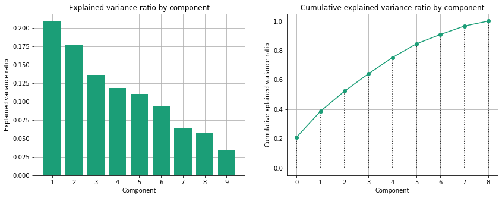

```python
var_fig, var_ax = plt.subplots(1, 2, figsize=(14,5))


xticks = np.arange(len(expl_var_rat))
var_ax[0].bar(xticks, expl_var_rat)
var_ax[0].set_xticks(xticks)
var_ax[0].set_xticklabels(xticks+1)
var_ax[0].set_xlabel('Component')
var_ax[0].set_ylabel('Explained variance ratio')
var_ax[0].set_title('Explained variance ratio by component')
var_ax[0].set_axisbelow(True)
var_ax[0].grid()

cum_var = np.cumsum(expl_var_rat)
var_ax[1].plot(cum_var, marker='o')
var_ax[1].vlines(x=xticks, ymin=0, ymax=cum_var, color='black', linestyle='dotted')
var_ax[1].set_axisbelow(True)
var_ax[1].grid()
var_ax[1].set_xlabel('Component')
var_ax[1].set_ylabel('Cumulative xplained variance ratio')
var_ax[1].set_title('Cumulative explained variance ratio by component');
```

There is no clear "elbow" pattern in the cumulative plot: it seems that **PCA cannot isolate the majority of the variance in just a few dimensions**. For this reason, we expect to to obtain the best results in a high number of dimensions, possibly all of them.

Nevertheless, dimensionality reduction was not our goal from the very start: the Avila dataset already has a very modest number of predictors. We are satisfied with removing just a few dimensions, as long as it is beneficial to some extent. Recall that the main feat of PCA is actually the decorrelation effect on the features, which might be helpful.  
Let us run PCA alongside Ridge to see how it performs.

```python
import re
pca_ridge_res = ridge_res[ridge_res['param_pca'] != 'passthrough']
best_record = pca_ridge_res.loc[pca_ridge_res['mean_test_score'].idxmax()]
# Grab number of components with a regex, because it's cool
best_n_comp = re.search(r'n_components=(\d)', str(best_record['param_pca'])).group(1)
print(f'Gridsearch (cross-validation) result:')
print(f'Best accuracy value of {best_record["mean_test_score"]:.3} ± {best_record["std_test_score"]:.1} obtained with lambda {int(best_record["param_ridge__alpha"])} and {best_n_comp} components.')
```

```
Gridsearch (cross-validation) result:
Best accuracy value of 0.521 ± 0.005 obtained with lambda 0 and 8 components.
```

Unfortunately, **we do not seem to obtain any improvement with PCA**: the best result we achieve is an even lower accuracy of $52\%$ by removing only one component.

We graphically inspect the complete results of the grid-search.

```python
def one_result_line_ridge(res, label, title, ax, linewidth=2, color=None):
    """
    Plots an errorbar plot to the given axis using the data contained in res. The output is assume to be the one of a RidgeClassifier and is plotted across the alpha values.

    Params:
        res (pandas DataFrame): dataframe with the columns mean_test_score, std_test_score, param_ridge__alpha
        label (str): label to show in the legend
        title (str): title of the axis
        ax (plt axis): axis to plot on
    """
    ax.set_xscale('log')
    ax.set_title(title)
    ax.grid(True)

    if color:
        ax.errorbar(x=res['param_ridge__alpha'], y=res['mean_test_score'], yerr=res['std_test_score'], label=label, linewidth=linewidth, color=color)
    else:
        ax.errorbar(x=res['param_ridge__alpha'], y=res['mean_test_score'], yerr=res['std_test_score'], label=label, linewidth=linewidth)

    # Annotating the maximum value (assuming there is one. Let's be serious, there won't be two)
    max_record = res.loc[res['mean_test_score'].idxmax()]
    xp = max_record['param_ridge__alpha']
    yp = max_record['mean_test_score']
    text = round(max_record['mean_test_score'], 2)
    ax.annotate(text=text, xy=(xp,yp))

    ax.legend()
    ax.set_xlabel('lambda')
```

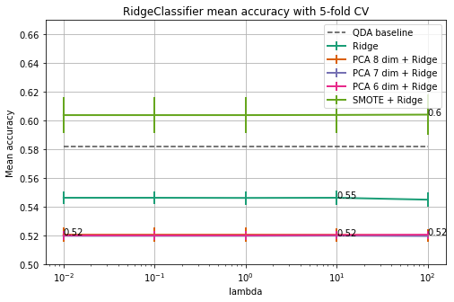

```python
ridge_fig, ridge_ax = plt.subplots(figsize=(8, 5))
ridge_ax.set_ylim(0.5, 0.67)
ridge_ax.set_ylabel('Mean accuracy')

ridge_ax.hlines(y=baseline, xmin=nopca_ridge_res['param_ridge__alpha'].min(), xmax=nopca_ridge_res['param_ridge__alpha'].max(), color='#4a4a4a', label='QDA baseline', linestyles='dashed')

one_result_line_ridge(nopca_ridge_res, 'Ridge', 'RidgeClassifier mean accuracy with 5-fold CV', ridge_ax)
one_result_line_ridge(ridge_res[ridge_res['param_pca'].astype(str) == 'PCA(n_components=8)'], 'PCA 8 dim + Ridge', 'RidgeClassifier mean accuracy with 5-fold CV', ridge_ax)
one_result_line_ridge(ridge_res[ridge_res['param_pca'].astype(str) == 'PCA(n_components=7)'], 'PCA 7 dim + Ridge', 'RidgeClassifier mean accuracy with 5-fold CV', ridge_ax)
one_result_line_ridge(ridge_res[ridge_res['param_pca'].astype(str) == 'PCA(n_components=6)'], 'PCA 6 dim + Ridge', 'RidgeClassifier mean accuracy with 5-fold CV', ridge_ax)
one_result_line_ridge(smote_ridge_res, 'SMOTE + Ridge', 'RidgeClassifier mean accuracy with 5-fold CV', ridge_ax)
```

Before moving on to the next section, we discuss some further possible interpretations of Ridge.

### Insight: the "hidden" relationship between PCA and Ridge

Let us first recap the concepts seen so far. As previously stated, **Ridge regression** is a linear model in which we infer a set of coefficients $\hat \beta$ by minimizing a $L_2$-regularized square loss function. Said function has a hyperparameter $\lambda$, which controls the regularization strength. For the sake of clarity, let us **rename that hyperparameter to $\alpha$**. As in any linear model, the fitted data is a linear combination of predictors:

$$\hat y=X\hat\beta^{\,\text{ridge}}=\sum_{i=1}^D x_i\hat\beta_i$$

The Ridge minimization problem has a **closed-form solution**: $\hat{\beta}^{\,\text{ridge}}=\left(X^T X+\lambda I\right)^{-1}X^T y$. This of course means that

$$\hat y=X\hat \beta^{\,\text{ridge}}=X\left(X^T X+\lambda I\right)^{-1}X^T y$$

On the other hand, PCA is a techinque which allows to transform a dataset $X$ into another dataset $E$ with decorrelated columns $\mathbf{e}_i$ and most of the variance enclosed in the first few columns. Namely, column $\mathbf{e}_i$ has variance $\lambda_i$.

By means of SVD decomposition, it is possible to prove that **the fitted values of a Ridge regression inference can be re-written in terms of PCA-transformed predictors**. Let $\mathbf{u}_i=\frac{\mathbf{e}_i}{\|\mathbf{e}_i\|}$. Then:

$$\hat y = X\hat{\beta}^{\,\text{ridge}} = \sum_{i=1}^D{\mathbf{u}_i\frac{\lambda_i}{\lambda_i+\alpha\,/n} \mathbf{u}_i^T y}$$

We can verbally describe the meaning of the above expression as follows: $\mathbf{u}_i^T y$ is equivalent to projecting $y$ on $\mathbf{e}_i$ (recall that $\mathbf{u}_i$ is just a normalized $\mathbf{e}_i$). After that projection, we are left with a scalar that we multiply by $\frac{\lambda_i}{\lambda_i+\alpha/n}$. If $\lambda_i \ll \frac{\alpha}{n}$ (i.e. if the variance captured by the $i^{\text{th}}$ transformed component is small), then this scalar will become small. The result is then used as a coefficient for $\mathbf{u}_i$ again, and the linear combination of all $\mathbf{u}_i$'s will form the fitted values $\hat y$.  
This means that estimating $\hat y$ with a Ridge regressor is like projecting $y$ on the PCA-transformed components of $X$, shrinking each projection proportionally to the variance captured by that component, and then using the resulting value (let us call it $c_i$) as a coefficient to compute $\hat y$ as a linear combination of the PCA-transformed components (normalized).

$$\hat y=X\hat\beta^{\,\text{ridge}}=\sum_{i=1}^D c_i\mathbf{u}_i$$

In other words, **we are still reconstructing the fitted values as a linear combination of the predictors (in a different base), but the coefficients $c_i$ shrink inversely to the amount of variance captured by that predictor**. The amount of shrinkage is controlled by the Ridge hyperparameter.

### Insight: a bayesian interpretation of Ridge

From a statistical standpoint, linear regression models the conditional probability of $y_i$ taking on some value as normally distributed with mean $\beta^T x_i$ and some variance $\sigma$. In other words, $y_i$ is a random variable such that

$$y_i| x_i, \beta \sim \mathcal{N}(\beta^T x_i,\;\sigma^2) \quad\Longrightarrow\quad \mathbb{P}(y_i| x_i, \beta)=\frac{1}{\sqrt{2\pi\sigma^2}}\exp{-\frac{(y_i- \beta^T x_i)^2}{2\sigma^2}}$$

The equality to the right can be used to compose a likelihood $L(\beta|X, y)$. Giving this problem a Bayesian interpretation, one may choose as prior for each component $\beta_k$ of the vector $\beta$ a set of $\text{i.i.d.}$ normals with mean $0$ and variance $\sigma_0$.

$$\beta_k\overset{iid}{\sim}\mathcal{N}(0, \sigma_0^2)$$

Analytically computing the posterior as $posterior \propto likelihood \cdot prior$ results in

$$ \pi(\beta| X, y) \propto \exp{(-\frac{1}{2\sigma^2}(\|y-X\beta\|^2 + \frac{\sigma^2}{\sigma^2_0}\sum_{j=1}^p{\beta_j^2}))} $$

Where we can set $\sigma^2/\sigma^2_0 := \lambda$. A **MAP point estimation of $\beta$ can be computed** by minimizing the negative logarithm of the above expression. This results in the **same formulation of the Ridge regression problem as initially illustrated**.  
In other words, the Ridge regression method can be seen as a MAP of a "bayesian linear regression" in which we use independent normal priors with mean $0$ and variance $\sigma_0^2$ for each $\beta_k$.

```python
# final_sampling_strategy = {
#     'F': 3200,
#     'E': 2500,
#     'H': 1500,
#     'X': 1000
# }

# print(f'Final sampling strategy: {final_sampling_strategy}')

# final_smote = SMOTE(sampling_strategy=final_sampling_strategy, random_state=random_state)

# X_whole_res, y_whole_res = final_smote.fit_resample(X, y)

# final_ridge.fit(X_whole_res, y_whole_res);
```

```python
final_ridge = Pipeline([('scaler', StandardScaler()), ('ridge', RidgeClassifier(alpha=100))])
final_smote_params_ridge = {
    'sampling_strategy': {
        'F': 3200,
        'E': 2500,
        'H': 1500,
        'X': 1000
    },
    'random_state': random_state
}

print(f'Final sampling strategy: {final_smote_params_ridge["sampling_strategy"]}')
```

```
Final sampling strategy: {'F': 3200, 'E': 2500, 'H': 1500, 'X': 1000}
```

# K-Nearest-Neighbors

It seems as though there is simply no way to linearly model the data distribution: so far, the best results were achieved by an SVM with an RBF kernel. We therefore turn towards an **instrinsically non-linear** and instrinsically multi-class classification algorithm.

[figure not shown]

> A *K-Nearest-Neighbor (kNN)* algorithm is typically described in the context of classification, but it is possible to adapt it for regression tasks. It can be applied over any domain $\mathcal{X}$ which allows the computation of a distance metric $d:\mathcal{X} \times \mathcal{X}\longrightarrow\mathbb{R}^+$.

> Let $\pi_i(x)$ be the $i^{\text{th}}$ farthest neighbor from $x$ according to some metric $d$, and let $S=\{(x_i, y_i)\}_i$ be the available training dataset. Then, to classify a new data point $x$:
> - consider $N_k = \{y_i\;\text{associated to}\;\pi_i(x):i\leq k\}$: i.e. the labels of the **k nearest neighbors** of $x$ accodring to the metric $d$.
> - classify $x$ with the majority label found in the set $N_k$

The most commonly employed metric $d$ is the *euclidian distance* $d(\mathbf{a},\mathbf{b})=\|\mathbf{a}-\mathbf{b}\|_2$. However, other choices are possible: for example, one could use the *Minkowski distance* $\left(\sum_{i=1}^D |a_i-b_i|^p\right)^{1/p}$, which introduces a new hyperparameter $p$. For $p=2$, we again obtain the euclidian distance; for $p=1$, the metric becomes the so-called *Manhattan distance*.

kNN is a relatively "theory-free" algorithm, in the sense that it can be very easily understood and implemented without mathematical jargon. However, theoretical notion should be kept in mind: **a kNN will be less effective in data with a high number of features, since points in very high dimensional spaces tend to be more sparse**, and distance becomes a less effective instrument for learning tasks.  
This is no concern when using the Avila dataset, since it has a relatively low number of predictors.

One furhter aspect should be taken into account when using a kNN:

> A too low $k$ may lead to overfitting; a too high $k$ may lead to underfitting.

In particular, in a $1$-NN every point will be able to "claim" at least a small decision region of its own: this will make the overall decision boundaries particularly jagged. Such aspect can be seen both negatively and positively: it might make the model more sensible to noise; on the other hand, **it can also be efficient at finding small, outlying clusters of minority classes which are surronded and outnumbered by other bigger clusters of different labels**.  
This is similar to the condition of our dataset, **in which there are some minority classes which, apparently, cannot be easily detected by means of linear models**, even with the aid of oversampling techniques.

One last important aspect of the kNN algorithm is the following:

> **A kNN does not infer any parameter form the data.** In this sense, more than an actual model, it can be seen as a heuristic method to guess the label of a test point $x$ given the other points in its proximity. This has the following implications:
> - basically no computation is involved in the training phase, since there is no real training process.
> - the "model" essentially consists in keeping all data points available at any time. In some cases, this might be a burden in terms of memory.
> - at test time, it is necessary to compute the distance of $x_{\text{test}}$ from all points in the dataset

We attempt to apply the usage of a kNN to our classification problem. We perform a gridsearch over different values of $k$ and $p$.

```python
from sklearn.neighbors import KNeighborsClassifier

knn_params = {
    'knn__n_neighbors': [1, 2, 3, 5, 10, 15, 20, 25],
    'knn__p': [1, 2, 3]
}
knn = Pipeline([('scaler', StandardScaler()), ('knn', KNeighborsClassifier())])
knn_gs = GridSearchCV(knn, knn_params, cv=5)
```

```python
knn_path = 'res/knn_gs2.csv'
knn_gs, knn_res = gridsearch_or_load(knn_gs, X, y, knn_path)
```

```
Read result from memory
```

```
Grisearch (cross-validation) result:
Best accuracy value of 0.898 ± 0.004 obtained with K=1, p=1.
```

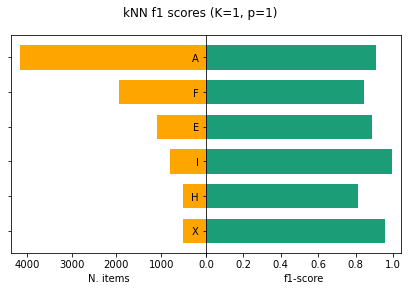

```python
best_record = knn_res.loc[knn_res['mean_test_score'].idxmax()]
print(f'Grisearch (cross-validation) result:')
print(f'Best accuracy value of {best_record["mean_test_score"]:.3} ± {best_record["std_test_score"]:.1} obtained with K={int(best_record["param_knn__n_neighbors"])}, p={best_record["param_knn__p"]}.')

best_knn_params = literal_eval(best_record['params'])
knn.set_params(**best_knn_params)
show_f1s(y, cross_val_predict(knn, X, y),
         f'kNN f1 scores (K={best_knn_params["knn__n_neighbors"]}, p={best_knn_params["knn__p"]})')
```

We can immediately verify that, with a nonlinear model, we easily achieve very good results with no particular tweaking other than some tuning on the hyperparameters $K$ and $p$. Inspecting f1-scores, it is possible to see that all classes are more or less equally represented.

We now visualize the results of the grid-search: the accuracy score plotted against the value of $K$, for each $p$.

```python
def one_result_line_general(res, estimator_name, param_name, label, title, ax, linewidth=2, color=None, scale='log'):
    """
    Plots an errorbar plot to the given axis using the data contained in res.

    Params:
        res (pandas DataFrame): dataframe with the columns mean_test_score, std_test_score, param_ridge__alpha
        estimator_name: estimator name in the pipeline, used to reconstruct column name
        param_name: name of the parameter to plot in the x axis
        label (str): label to show in the legend
        title (str): title of the axis
        ax (plt axis): axis to plot on
    """
    if scale:
        ax.set_xscale('log')
    ax.set_title(title)
    ax.grid(True)

    if color:
        ax.errorbar(x=res[f'param_{estimator_name}__{param_name}'], y=res['mean_test_score'], yerr=res['std_test_score'], label=label, linewidth=linewidth, color=color)
    else:
        ax.errorbar(x=res[f'param_{estimator_name}__{param_name}'], y=res['mean_test_score'], yerr=res['std_test_score'], label=label, linewidth=linewidth)

    # Annotating the maximum value (assuming there is one. Let's be serious, there won't be two)
    max_record = res.loc[res['mean_test_score'].idxmax()]
    xp = max_record[f'param_{estimator_name}__{param_name}']
    yp = max_record['mean_test_score']
    text = round(max_record['mean_test_score'], 2)
    ax.annotate(text=text, xy=(xp,yp))

    if label:
        ax.legend()
    ax.set_xlabel(param_name)
```

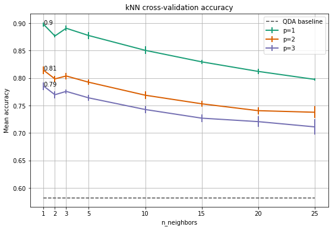

```python
knn_fig, knn_ax = plt.subplots(figsize=(9,6))
knn_ax.hlines(y=baseline, xmin=knn_res['param_knn__n_neighbors'].min(), xmax=knn_res['param_knn__n_neighbors'].max(), color='#4a4a4a', label='QDA baseline', linestyles='dashed')
for p in knn_params['knn__p']:
    one_result_line_general(knn_res[knn_res[f'param_knn__p']==p], 'knn', 'n_neighbors', f'p={p}', 'kNN cross-validation accuracy', knn_ax, scale=None)
knn_ax.set_xticks(knn_params['knn__n_neighbors']);
knn_ax.set_ylabel('Mean accuracy');
```

Coincidentally, the best setting is the previously discussed one: $K=1$. Apparently, increasing the sensibility of the model helps in catching the small clusters of minority classes of the data: all of them are classified rather well, some even better than the most populated class `A`. This tradeoff seems to be the best one to achieve a high accuracy.

We are satisfied with the $90\%$ accuracy obtained with a kNN, and move on to the last model.

```python
# Commented and replaced with jpg for faster rendering
# visual_knn = Pipeline([('scaler', StandardScaler()), ('knn', KNeighborsClassifier(n_neighbors=1))])
# visual_knn.fit(X.to_numpy(), y.cat.codes.to_numpy());
```

```python
# knnfig, knnax = plt.subplots(1,2, figsize=(12, 5))

# dec_bound(visual_knn, X.to_numpy(), y.cat.codes.to_numpy(), knnax[0], columns=X.columns, feature_index=(0,1))
# dec_bound(visual_knn, X.to_numpy(), y.cat.codes.to_numpy(), knnax[1], columns=X.columns, feature_index=(2,3))

# knnfig.suptitle('kNN decision boundaries (k=1)');
```

[figure not shown]

```python
final_knn = Pipeline([('scaler', StandardScaler()), ('knn', KNeighborsClassifier(n_neighbors=1, p=1))])
# final_knn.fit(X, y); Not needed anymore, final fit is done at the end
```

# Decision trees and random forests

The last class of algorithms we employ is the **Decision Tree**. From a conceptual standpoint, it is a relatively simple technique, and has the benefit of a higher **interpretability** with respect to other algorithms.

[figure not shown]

> A *Decision Tree* is a classification/regression model which consists in assigning labels to a sample by taking decisions based on the values of its attributes in a **hierarchical fashion**. More specifically:
> - At each node, a decision is taken based on the truth value of the expression $x_j\leq\theta$, where $x_j$ is some attribute and $\theta$ is **threshold** value inferred during training.
> - Each **leaf** of the tree assigns an estimated target value
> - Each leaf corresponds to a "cell" (i.e. a *hyper-rectangle*) of the input space $\mathcal{X}$. We define an hyper-rectangle as the set of $n$-dimensional points whose values are all contained within certain ranges: $\left\{(x_1\dots x_n): x_j\in[a_j, b_j]\;\forall j\right\}$

The main weakness of a decision tree is its tendency to **overfit** when grown too much. Because of this, it is necessary to make sure that the growing of the leaves stops at a certain point. We will adress such issue later.  
The main problem now is how to actually build a decision tree: a possible option is the **ID3 Algorithm**.

## ID3 algorithm

> The *Iterative Dichotomiser 3 (Quinlan, 1986)* is an algorithm to construct a decision tree starting from a dataset $S=\{(x_i, y_i)\}_i$. ID3 can be described as:
> - **Greedy**: decisions are taken locally according to the best possible split available at the moment.
> - **Recursive**: at each call of the function `ID3(S, Attr)` we examine the "gain" that we would achieve by splitting the data on some feature $x_j$; we choose the feature that yields the most gain to split on, and obtain further subsets `S_i` which we again pass to the function as argument.
> - **Categorical** (...or not): the original version of this algorithm works only on categorical features. However, it can be generalized to numerical features as well.

> In order to formulate the algorithm, we first assume we have some "gain" function $\text{Gain}(S,j)$ which takes a subset of data $S$ and an index $j$ and **evaluates how much we can gain from splitting $S$ according to the values of feature $x_j$**. This "gain" usually quantifies how well points of different classes are being separated.  
> The ID3 can then be described by the following pseudocode:

> ```
> ID3(S, attrs):
>    // S: subset of data, attrs: attributes to consider when deciding what to split on
>    if all x ∈ S have the same label y:
>        return leaf node of label y
>
>    if attrs = ∅: // all available attributes have already been used
>        return leaf node of label {majority label of S}
>
>    j = argmax_i {Gain(S,i)} // find attribute of maximum gain
>    for value in x_j:
>            T_j = ID3(S[S.x_j == value], attrs.drop(x_j)) //originally, ID3 we splits on each x_j only once
>
>    return a decision node which splits on attribute x_j and has T_1 ... T_n as child nodes
> ```

While the original ID3 allowed splitting on a certain feature only once, the implementation we use permits to select he same attribute twice for a split in different parts of the tree.

> Once the tree is constructed, to infer the label of a new sample $x_f$, **we traverse the whole tree according to the conditions found in each node**: once we reach a leaf associated to label $y_i$, we assign that label to $x_f$.

## Gain and impurity metrics

We now need to establish a **gain** function. The definition of gain is often based on another metric called **impurity**.

An impurity measure $I$ is computed on a set of samples $S=\{(\mathbf{x}_i, y_i)\}_i$, mostly based on their labels, and possibily with some conitions on their attributes. For example, we may wanto to take into account only the labels whose records have a particular value $a$ on attribute $x_j$ (i.e. only count $y_i : (\mathbf{x}_i)_j=a$).  
Intuitively, **an impurity function measures how diverse the labels $y_i$ are within a given set $S$**. If most labels in $S$ have the same value, then the impurity will be low; instead, if the labels take on several different values, then $S$ will have high impurity.

> Let us momentarily assume that we do have some function $I(S)$ that measures the impurity of the set $S$. Of course, when deciding which attribute to split on in a decision tree, **we want to pick the attribute that will minimize the impurity of the resulting subsets**. We therefore define the gain function of a split as *(Shalev-Shwartz, 2014)*:

> $$\text{Gain}(S,j)=I(S)-\sum_{a_k\in x_j}\mathbb{P}(x_j=a_k)\cdot I(S|x_j=a_k)$$

> Where $\mathbb{P}(x_j=a_k)$ is defined as the frequency of items with attribute $x_j=a_k$ within $S$: $\mathbb{P}(x_j=a_k):=N_{x_j=a_k}\,/|S|$.  
> $I(S|x_j=a_k)$ is the impurity of $S$ when taking into account only records with $x_j=a_k$.

**The gain of a split essentially measures the difference of impurity level before and after the split**. The impurity after the split is determined by the impurity of each subset resulting from the split, weighed on the size of the subset itself.

The only missing aspect is an explicit definition of the impurity measure: there are several possible choices for it, and we are going to illustrate the most popular ones.

> Let us define the frequency of occurrence of label $y_i$ inside of set $S$ as $p_{y_i}:=N_{y_i}\,/|S|$.
> - **GINI index**: $I(S)=1-\sum_{y_i}p_{y_i}^2=\sum_{y_i}p_{y_i}\left(1-p_{y_i}\right)$
> - **Entropy**: $I(S)=H(S)=-\sum_{y_i}p_{y_i}\log p_{y_i}$
> - **Train error**: $I(S)=1-\max_{y_i}\{p_{y_i}\}$

In our analysis, we will use the GINI index (the default impurity measure in scikit-learn).

## Extending ID3 to numerical features

The ID3 we described so far is only able to handle categorical variables. The idea for extending it to numerical features is to **take the range of each attribute $x_i$, try to split it according to different thresholds, and select the best one**.

To do so, it is sufficient to modify the implementation of the $\text{Gain}$ function according to the following pseudocode:

> ```
> Gain_improved(S, j):
>    // S: set of data, j: index of an attribute found in S
>    if x_j is categorical:
>        return Gain(S, j)
>
>    for each value a_k ∈ x_j:
>        θ <- a_k // set a_k as threshold value
>        split S in two sets: {S_l | x_j <= θ} and {S_r | x_j > θ}
>        evaluate the impurity of this split as normal
>
>    find θ_max that results in the maximum impurity reduction
>    return gain of split on θ_max
> ```

> After checking all features, if $x_j$ turns out to be the most convenient attribute to split on, then **the node will split according to the rule $x_j\leq\theta_{max}$**. Thus, it will result in two sub-brances.

## Overgrowing and overfitting

As previously mentioned, a Decision Tree can very easily overfit without imposing any boundary on its depth.  
This is because **each leaf may end up containing only one training sample**, which would result in a too specific classification (i.e. overfitting). For this reason, it is always recommended to set a limit to the tree's growth, which can be expressed in several different ways.

In our case, we will set a limit to the following parameters:

- **maximum depth**: limits the maximum length of the path from the root to any leaf. Once that depth is hit by a branch, the current node is transformed into a leaf associated to its current majority label.
- **minimum samples per leaf**: sets the minimum amount of items that must be contained in a node for it to become a leaf. If a split would result in any node having fewer items than the minimum quantity, that split cannot be performed.
- **minimum impurity decrease**: any split must correspond to a minimum amount of gain in order to be performed. If this does not happen, then the split is not performed. For this evaluation, the gain is weighted on the number of samples contained in the current node over the total number of samples.

We will select the most appropriate values for these hyperparameters via cross validation.

## From trees to forests: bootstrapping

Decsion trees are fast to train and have a good degree of interpretability, but they often perform badly when compared to other more complex models. This issue is often tackled by using **ensemble methods: multiple versions of the same model are trained on different data, and at test time, the output of all models is summarized as one single evaluation**. This summarization is often an average of all outputs of the ensemble for each single test item.

The usual way to do so is the **bootstrapping** technique, whereby it is possible to obtain different versions of the model by **slightly varying the training data for each model instance**.

> When given a dataset $S$, it is possible to simulate the availability of more data by sampling with repetition from $S$. By doing so, we can create any number $B$ of new datasets that are slight variations of $S$. This procedure is known as **bootstrapping**.

Once we have our $B$ new datasets, we can train $B$ classifiers on those. This is the idea behind the so-called **Random Forest** model.

> A **Random Forest** *(Breiman, 2001)* consists of $B$ decision trees trained on $B$ different datasets bootstrapped from the same original dataset $S$. To add further randomness to the tree construction, **only a random subset of the available features is considered at each split**: usually, for $p$ available features, $\sqrt p$ random features are considered. This helps in making the trees decorrelated, which in turn has the effect of reducing the overall variance of the ensemble *(Hastie, 2009)*.

> At test time, a sample $x_f$ is classified by all $B$ trees. To obtain the final label, a **majority vote can be performed**.  
> One possible alternative (implemented by scikit-learn) is to **have the tree predict probabilities instead of actual labels**. Each leaf node is associated to a set of probabilities $\{p_i\}_i$, one for each label. The probability of a label is the fraction of items of that label that falls within that leaf over the total items that fall in that leaf, all at training time: $p_i=N_{y_i}\,/N_{\text{leaf}}$. Then, the output of each decision tree becomes a probability vector, and **the ouput of the forest can also be the average probability of each label**.

Even in the case of discrete prediction of a label, we can encode it as a one-hot vector to come to a general mathematical summary of the prediction of a boostrap-based ensemble. Let $h_b$ be the predictor trained on the $b^{th}$ boostrapped dataset; then, the decision function of the ensemble is

$$h_{\text{ens}}(x)=\frac{1}{B}\sum_{b=1}^B h_b(x)$$

The advantages of using a random forest instead of a single tree are:

- an evident increase in accuracy
- in general, even for models other than trees, the variance of an ensemble is much decreased with respect to one of a single model. This is mathematically true because, by averaging $B$ i.i.d. random variables $\mathcal{Z}_1\dots\mathcal{Z}_B$ of variance $\sigma^2$, we obtain a new random variable of variance $\sigma^2/B$.

We directly employ the Random Forest model. We find the best hyperparameters (among the ones described above) via cross-validation.

```python
from sklearn.ensemble import RandomForestClassifier

forest = Pipeline([('scaler', StandardScaler()), ('forest', RandomForestClassifier(random_state=random_state))])
forest_params = {
    'forest__n_estimators': [100, 300, 400, 500],
    'forest__max_depth': [5, 10, 15, 20],
    'forest__min_samples_leaf': [5, 10, 15, 25],
    'forest__min_impurity_decrease': [0.0, 0.1, 0.2, 0.5],
    'forest__oob_score': [True],
    'forest__random_state': [random_state]
}

forest_gs = GridSearchCV(
    forest,
    forest_params,
    n_jobs=-1,
    cv=5,
    verbose=3
)
```

```python
forest_path = 'res/forest_gs.csv'
print('Performing gridsearch...')
forest_gs, forest_res = gridsearch_or_load(forest_gs, X, y, forest_path)
```

```
Performing gridsearch...
Read result from memory
```

After having completed the training, we can visually inspect one of the many trees in the forest.

```python
best_record = forest_res.loc[forest_res['mean_test_score'].idxmax()]
best_params = literal_eval(best_record['params'])

forest.set_params(**best_params)
forest.fit(X,y);
```

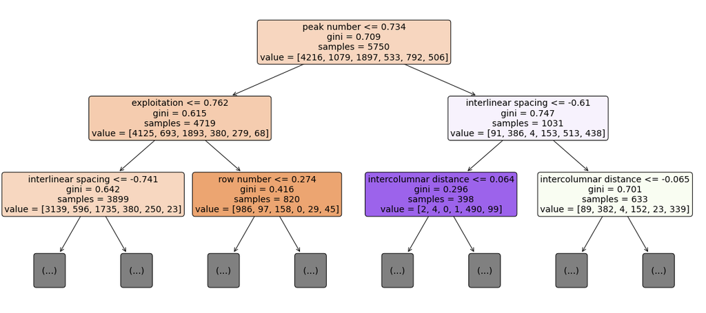

```python
from sklearn.tree import plot_tree
fig_tree, ax_tree = plt.subplots(figsize=(20,9))

plot_tree(
    forest['forest'].estimators_[11],
    max_depth=2,
    feature_names=X.columns,
    filled=True,
    rounded=True,
    fontsize=14
);
```

```
Best accuracy value of 0.963 ± 0.007 obtained with parameters:
max_depth = 20
min_impurity_decrease = 0.0
min_samples_leaf = 5
n_estimators = 300
oob_score = True
random_state = 1153
```

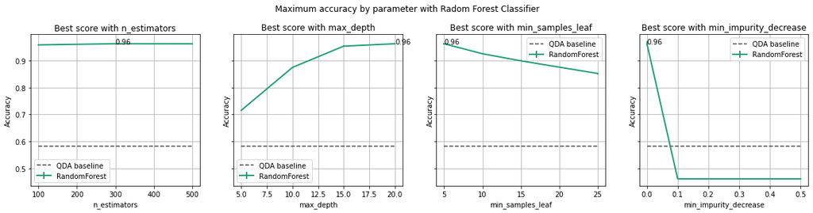

```python
# Results display
fig, axes= plt.subplots(1, 4, figsize=(20, 4), sharey='row', subplot_kw={'ylabel': 'Accuracy'})
fig.suptitle('Maximum accuracy by parameter with Radom Forest Classifier', y=1.03)

for param, ax in zip(['n_estimators', 'max_depth', 'min_samples_leaf', 'min_impurity_decrease'], axes):
    agg_res = forest_res.groupby(f'param_forest__{param}').agg({'mean_test_score':'max', 'std_test_score':'mean'})
    agg_res[f'param_forest__{param}'] = agg_res.index
    one_result_line_general(agg_res, 'forest', param, 'RandomForest', f'Best score with {param}', ax, scale=None)
    ax.hlines(y=baseline, xmin=forest_res[f'param_forest__{param}'].min(), xmax=forest_res[f'param_forest__{param}'].max(), color='#4a4a4a', label='QDA baseline', linestyles='dashed')
    ax.legend()

# Printing best absolute result


print(f'Best accuracy value of {best_record["mean_test_score"]:.3} ± {best_record["std_test_score"]:.1} obtained with parameters:')
for param, val in best_params.items():
    p_name = re.search(r'__(.*)', param).group(1)
    print(f'{p_name} = {val}')
```

The results are outstanding: we effortlessly **obtain a $96\%$ accuracy**.  
The minimum impurity decrease only yields valid results when set to less than $0.1$: this is reasonable, since $0.1$ is a very sensible reduction. Some trees may not even be able to get that at the first split, hence ending up as unsprouted roots.  
On the other hand, we obtain the best accuracy with the highest maximum depth and the lowest minimum samples per leaf. Both those details hint at possible overfitting - we shall assess that at test time.

Yet, it is still unusual that a random forest was able to model this dataset so effctively, easily outperforming more complex algorithms such as SVMs. We suspect that **there may be something about the Avila dataset that makes it very suitable for modeling via decision trees**. From here on, we can only attempt to make bold assumptions on such motivation; and we shall indeed do that, after we examine the decision boundaries generated by the trained random forest.

```python
# Replanced with static jpg image for faster rendering
# num_y = y.cat.codes.to_numpy()
# num_X = X.to_numpy()
# forest.fit(num_X, num_y)
```

```python
# fig, axes = plt.subplots(1, 3, figsize=(20,5), subplot_kw={})
# fig.suptitle('Decision regions of Random Forest with different couples of features')

# fts_indexes = [(3,1), (4,1), (0,1)]
# for ax, idxes in zip(axes, fts_indexes):
#     dec_bound(forest, num_X, num_y, ax=ax, columns=X.columns, feature_index=idxes)
```

[figure not shown]

The second figure clearly shows the aforementioned rectangular decision regions, upon which several forests seem to agree. The other two decision regions appear more jagged - of course, this is the result of several trees working together.

## Why are trees so effective on Avila?

As previously discussed, decision trees have the benefit of being **more interpretable** than other models. This intepretability is partially lost in an ensemble of hundreds of trees, but we can try to retain some of it by using a metric called **Mean Decrease Impurity importance (MDI)** *(Breiman, 2001)*. It is, in essence, a **weighted average of the impurity that a single feature contributes to decrease throughout the whole forest**. It must be computed for each individual feature, and can give an idea of how important that feature is to the model: the higher the value, the higher the relevance.

We have already defined a metric for quantifying a decrease of impurity: the **Gain** function. Now let us denote as:

- $t$ a node on some tree, and $N_t$ the number of samples that passed thourgh it at training time
- $G(t)$ the gain value generated by the split at note $t$
- $v(t)$ a function which, given a node $t$, returns the attribute that the node was split on
- $T$ a tree in the forest, and $N_T$ the total number of trees
- $N$ the size of all bootstrapped datasets
- $p(t)$ the proportion of samples of the dataset reaching node $t$, computed as $p(t)=N_t\,/N$

Then we define the **MDI** (i.e. the importance) of a **feature $x_j$** as

$$\text{MDI}(x_j)=\frac{1}{N_T}\sum_T\sum_{t\in T\,:\,v(t)=x_j}p(t)G(t)$$

scikit-learn automatically computes this value and normalizes it over all the training features: we can display it visually. We use different colors for page, column and row attributes.

```python
ft_importances = pd.Series(
    data=forest['forest'].feature_importances_,
    index=X.columns
).sort_values(ascending=False)
```

```python
ft_importances = pd.DataFrame({
    'importance': forest['forest'].feature_importances_,
    'type': ['page', 'page', 'page', 'column', 'column', 'row', 'row', 'row', 'row']
}, index=X.columns).sort_values('importance', ascending=False)
```

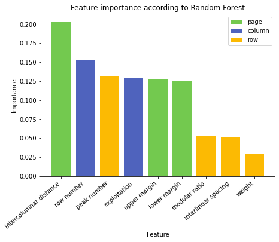

```python
fig, aximp = plt.subplots(figsize=(7, 5),
                          subplot_kw={
                              'title': 'Feature importance according to Random Forest',
                              'xlabel': 'Feature',
                              'ylabel': 'Importance',
                              'xticks': range(len(ft_importances)),
                          })

colors = {
    'page': '#73c94f',
    'column': '#4f63bd',
    'row': '#fcba03'
}

for type_col, color in colors.items():
    mask = (ft_importances['type'] == type_col)
    data = ft_importances[mask]
    pos = np.argwhere(mask).flatten()
    aximp.bar(pos, data['importance'], color=color, label=type_col)

aximp.legend()
aximp.set_xticklabels(ft_importances.index, rotation=40, ha='right');
```

These feature importances are very different from the ones obtained with AIC; but then again, those were computed with Logistc Regression, a radically different model.

At this point, some hypotheses can be made on why a random forest is so effective on the Avila dataset.  
With the exception of `peak number`, the most important features for the model are the ones relative to the **whole page** and the **columns**.  
Let us now recall that the Avila dataset has a **hierarchical structure**: for each page, there have two columns; for each column, samples representing 4 rows are taken *(De Stefano, 2018)*. This means that **all row samples belonging to the same column will share attributes relative to that column AND page; samples belonging to different columns, but same page, will still share the attributes relative to the page**.

[figure not shown]

This hierarchical structure might be the reason why decision trees work so well on Avila: **they too are intrinsically hierarchical**, and therefore may be particularly suited to capturing these patterns in the data. By splitting on the "higher level" features, i.e. the ones relative to columns and page, they may be able to conveniently **separate several samples from the same class at once**, hence achieving an initial major impurity reduction. In this sense, the rows features would play the role of the last subtle details which help in the final, definitive distinction of a scribe from another.

Of course this is not just very ambitious guesswork: all these assumptions are formulated based on the feature importances generated by the random forest, which visibly describe page and column features as the most relevant for the classification task.

For one last validation of the effectiveness of the random forest classifier, we can check the **Out-of-Bag** error.

> *Out-of-Bag (OOB)* error is an evaluation metric that can be used as a validation technique on bootstrapped classifiers. By definition, a boostrapped dataset is sampled with replacement from the original dataset: hence, **there may be samples from the original dataset that do not make it into the boostrapped set**. These are called "Out-of-Bag" samples for that specific boostrapped set, and they are not seen during training by the decision tree trained on that set.

> OOB error is computed for a sample $\mathbf{x}_i\in S$ by **predicting its label with the forest, but only using the trees for which $\mathbf{x}_i$ is an OOB sample**. This can be done to check wether the individual models of the enseble are generalizing well to new unseen data.

The OOB error rate can be a way to assess the quality of the model when there is not enough data for holding out a validation set; anyhow, it constitutes a good metric even plenty of data is available.

In scikit-learn, the **OOB accuracy is estimated instead of the error rate**: the `RandomForestClassfier` class has a `oob_score_` attribute whose value is computed ad $1-\text{OOB error rate}$. Let us check it.

```python
final_forest = forest.set_params(**best_params)
final_forest.fit(X, y);
```

```python
print(f'Out-of-bag score of the final Random Forest: {final_forest["forest"].oob_score_:.3}')
```

```
Out-of-bag score of the final Random Forest: 0.975
```

It seems that the forest is actually generalizing the data well. We shall have final confirmation of this at test time.

# Final evaluation on test set

The final step of every data analysis pipeline is the testing phase. **Prior to the whole analysis, it is necessary to set aside some data that will never be used**, not even for validation: this consitutes a **simulation of what the trained models may encounter when used on real data**.

One possible approach to the final testing phase would be to just fit the models to the whole training set once, and assess their performance on the test data.

A slightly more elaborate option is to again use **bootstrapping** to more thoroughly establish not only the accuracy of the model, but also its **variance**, i.e. how much the model's behavior changes when trained on slightly different sets of data. This value, together with the mean accuracy score, contributes to giving a more complete idea of how trustworthy the model is.

To apply **bootstrapping** at test time, we do as follows: we create **$B$ slightly different training sets** by bootstrapping on all the training data. For each bootstrapped set, we train the model on it (applying SMOTE with the proper parameters when necessary) and evaluate the accuracy score of the model on the test set. By doing so, **we obtain $B$ different accuracy scores for each model, from which we can compute a mean and a standard deviation**.

We perform the operation with $B=5$, print out the results, and illustrate them as a bar chart. **Each bar represents the mean accuracy of the model, while the black error bars on top of each bar represent the standard deviation**.

```python
from sklearn.utils import resample
final_result_path = 'res/final4.csv'

X_test = avila_test.drop('monk', axis='columns')
y_test = avila_test['monk']
print(f'Test dataset imported.')
print(f'Test set size: {len(X_test)}')
```

```
Test dataset imported.
Test set size: 9217
```

After having imported the test set, we **remove outliers by using the Isolation Forest trained at the beginning of our analysis**.

```python
outliers_test_mask = (isol_for.predict(X_test) == -1)
n_out_test = np.sum(outliers_test_mask)
print(f'Isolation Forest found {n_out_test}.')

to_keep_test = np.logical_not(outliers_test_mask)
X_test = X_test[to_keep_test]
y_test = y_test[to_keep_test]

print(f'Removed {n_out_test} outliers.')
print(f'New test dataset size: {len(X_test)}')
```

```
Isolation Forest found 236.
Removed 236 outliers.
New test dataset size: 8981
```

The amout of outliers found in the test set is comparable to the one found in the training set. We can proceed to the final evaluation.

```python
# Getting all the final results
final_models = [qda_final, svm_final, final_lr, final_ridge, final_knn, final_forest]
names = ['QDA', 'SVM', 'Logistic Regression', 'Ridge Classifier', 'kNN', 'Random Forest']

n_bootstraps = 5


if exists(final_result_path):
    final_score = pd.read_csv(final_result_path, index_col=0)
else:
    final_score = pd.DataFrame(index=names)

    for i in range(n_bootstraps):
        print(f'Bootstrap {i+1}')
        X_train_boot, y_train_boot = resample(X, y, random_state=i, stratify=y)
        # Save scores in dataframe. Rows: model. Columns: rounds, then mean and std
        scores_boot = pd.Series(index=names)
        for model, name in zip(final_models, names):
            # Logistic reg and ridge need SMOTE on training set. QDA needs two attributes dropped
            if name == 'Logistic Regression':
                print('(Resampling...)', end=' ')
                final_smote = SMOTE(**final_smote_params_lr)
                X_train_boot, y_train_boot = final_smote.fit_resample(X_train_boot, y_train_boot)
            elif name == 'Ridge Classifier':
                print('(Resampling...)', end=' ')
                final_smote = SMOTE(**final_smote_params_ridge)
                X_train_boot, y_train_boot = final_smote.fit_resample(X_train_boot, y_train_boot)

            # Training the model (whatever it is) and predicting on test

            model.fit(X_train_boot, y_train_boot)
            y_pred = model.predict(X_test)
            score = accuracy_score(y_test, y_pred)
            scores_boot[name] = score
            print(f'\t - {name} scored {score:.3}')

        final_score[f'round_{i}'] = scores_boot

    # Save final scores to disk
    final_score.to_csv(final_result_path)
```

```python
verdict = final_score.copy()
verdict['mean'] = final_score.mean(axis=1)
verdict['std'] = final_score.std(axis=1)
```

```
Final test accuracy:

QDA: 0.57 ± 0.0073
SVM: 0.84 ± 0.0028
Logistic Regression: 0.64 ± 0.0022
Ridge Classifier: 0.61 ± 0.0041
kNN: 0.88 ± 0.0027
Random Forest: 0.97 ± 0.0048
```

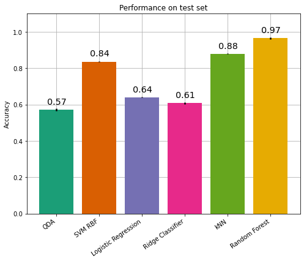

```python
fig, final_ax = plt.subplots(figsize=(8, 6),
                             subplot_kw={
                                 'title': 'Performance on test set',
                                 'ylabel': 'Accuracy',
                                 'xticks': range(len(verdict))
                             })

for i, (index, row) in enumerate(verdict.iterrows()):
    final_ax.errorbar(
        #x=range(len(verdict)),
        x=i,
        y=row['mean'],
        yerr=row['std'],
        marker=' ',
        linestyle=' ',
        fillstyle='none',
        elinewidth=2.5,
        markersize=10,
        markeredgewidth=2,
        color='black'

    )

    final_ax.bar(
        #x=range(len(verdict)),
        x=i,
        height=row['mean']
    )

final_ax.grid()
final_ax.set_axisbelow(True)
final_ax.set_xticklabels(['SVM RBF' if name=='SVM' else name for name in names], rotation=35, ha='right');
final_ax.set_ylim(top=1.1)

for xp, yp in enumerate(verdict['mean']):
    final_ax.annotate(f'{yp:.2f}', xy=(xp,yp), xytext=(xp-0.22,yp+0.03), fontsize='x-large')

print('Final test accuracy:\n')
for idx, row in verdict.iterrows():
    print(f'{idx}: {row["mean"]:.2} ± {row["std"]:.2}')
```

## Conclusions

All models roughly **maintain their validation performance** and have relatively low variance. The **random forest** was not overfitting after all, and it is **confirmed to be the most suitable model for this task with a $97\%$ accuracy. kNN and SVM with RBF kernel shortly follow**, with $88\%$ and $84\%$ accuracy respectively. This confirms that nonlinear models are more effective on this dataset than linear ones, which all score $61$ to $64\%$ (including SVM with a linear kernel, which did not make it to the final test stage). Despite being technically nonlinear, **QDA takes the last place**, losing one percentage point of accuracy from the validation score.

Aside from numerical results, it must be pointed out that the data from the test set was also extracted from the Avila bible, and was obtained with the same instrumentation and processed in the same way as the training data. Moreover, test and train set have the same class proportions. Therefore, it is safe to say that **the test set closely mirrors the distribution of the training set**.  
In a scenario in which the samples are extracted from **different sources and with different equipment, these results may change drastically**: page features may not be as relevant anymore, since the layouts of different tomes may vary. In such case, a different analysis would have to be carried out by giving more relevance to features which are closely related to the scribe's handwriting, such as `modular ratio` and `peak number`. This could hurt the performance of the random forest, which seems to heavily rely on page features, and perhaps favor models like logistic regression, which instead appear to favor row-related attributes such as the ones mentioned above.

However, this is all just supposition that would have to be backed up by concrete and more in-depth investigation. This is outside the scope of this dissertation, whose aim was to dissect the Avila dataset as it is, with a rather pedagogic approach. We are satisfied with the results of this analysis and set aside these last assumptions for future work.

# References

C. De Stefano, M. Maniaci, F. Fontanella, A. Scotto di Freca, *Reliable writer identification in medieval manuscripts through page layout features: The 'Avila' Bible case, Engineering Applications of Artificial Intelligence*, Volume 72, 2018, pp. 99-110.

F. T. Liu, K. M. Ting, Z. Zhou, *Isolation Forest*, Eighth IEEE International Conference on Data Mining, 2008

M. Breunig, H. Kriegel, R. Ng, J. Sander, *LOF: Identifying Density-Based Local Outliers*, ACM Sigmod Record. 29. 93-104, 2000

B. Schölkopf, R. Williamson, A. Smola, J. Shawe-Taylort, J. Platt, *Support Vector Method for Novelty Detection*, Advances in Neural Information Processing Systems 12, 1999

C. Cortes, V. Vapnik, *Support-vector networks*, Machine Learning volume 20, pp. 273–297, 1995

D. Tax, R. Duin, *Support Vector Data Description*, Machine Learning, 54, 45–66, 2004

V. Cherkassky, *Learning from Data: Concepts, Theory, and Methods (Second edition)*, 2007, section 9.10, pag. 464

T. Hastie, R. Tibshirani, J. Friedman, *The Elements of Statistical Learning: Data Mining, Inference, and Prediction*, Second Edition, Springer, 2009

N. Chawla, K. Bowyer, O. Hall, W. Kegelmeyer, *SMOTE: synthetic minority over-sampling technique*, Journal of artificial intelligence research, 16, 321-357, 2002

H. Nguyen, E. Cooper, K. Kamei, *Borderline over-sampling for imbalanced data classification*, International Journal of Knowledge Engineering and Soft Data Paradigms, 3(1), pp.4-21, 2009

F. Last, G. Douzas, F. Bacao, *Oversampling for Imbalanced Learning Based on K-Means and SMOTE*, 2017

H. Haibo, Y. Bai, E. Garcia, S. Li, *ADASYN: Adaptive synthetic sampling approach for imbalanced learning*, IEEE International Joint Conference on Neural Networks (IEEE World Congress on Computational Intelligence), pp. 1322-1328, 2008

H. Akaike, *A new look at the statistical model identification*, IEEE Transactions on Automatic Control, 19: 716–723, 1974

A. Hoerl, R. Kennard, *Ridge Regression: Biased Estimation for Nonorthogonal Problems*, Technometrics: A journal of statistics for the physical, chemical and engineering sciences, Vol. 12, 1970

J. Suykens, J. Vandewalle, *Least squares support vector machine classifiers*, Neural processing letters, 1999

J. Quinlan, *Induction of Decision Trees*. Machine Learning 1, 1, 81–106, 1986

L. Breiman, *Random Forests*, Machine Learning 45, 5-32, 2001

S. Shalev-Shwartz, S. Ben-David, *Understanding Machine Learning: From Theory to Algorithms*, Cambridge University Press, 2014